# ACTG175 (Binary): Comparing Selection Rules

OR-scale comparison across sg_focus × selection_rule cells

**Setup (click to expand)**

```r
# Initialize timing
t_doc_start <- proc.time()
timings <- list()
```

# 1 Introduction

The structure is:

1. **Data setup + ITT** — identical to the single-rule analyses.
2. **Comparison run** — one call to `compare_selection_rules()` that handles the loop, captures each run’s `CANDIDATE EVALUATION PREVIEW` + `CANDIDATE EVALUATION SUMMARY` banners, builds the Pareto-frontier plots, and computes split-derived CIs.
3. **Per-combo diagnostics** — replay of captured console output, individual frontier plot/table/narrative for each combination.
4. **Side-by-side composition** — patchwork-composed plot panel for direct visual comparison.

Bootstrap, cross-validation, and the combined forest plot are **deliberately omitted** so the document stays focused on the *selection mechanism* and the comparison reads as a tight diagnostic of the rule axis alone.

# 2 Setup

## 2.1 Load Required Packages

```r
suppressPackageStartupMessages({
  library(forestsearch)
  library(speff2trial)       # ACTG175 dataset
  library(data.table)
  library(ggplot2)
  library(gt)
  library(future)
  library(patchwork)         # for side-by-side plot composition
})

# Source the comparison wrapper.  When this graduates into the package
# (copy compare_selection_rules.R into R/ and run devtools::document()),
# this source() line can be removed.
#source("compare_selection_rules.R")

# Set ggplot theme
theme_set(theme_minimal(base_size = 12))
```

## 2.2 Analysis Parameters

```r
# ─── Parallel processing ────────────────────────────────────────────────
n_cores <- max(1L, floor(0.95 * parallel::detectCores(logical = FALSE)))

# ─── Reproducibility ────────────────────────────────────────────────────
analysis_seed <- 8316951L
set.seed(analysis_seed)

# ─── Confounders ───────────────────────────────────────────────────────
cont_vars <- c("age", "preanti", "wtkg", "karnof", "cd40", "cd80")
bin_vars  <- c("hemo", "homo", "drugs", "race", "gender", "symptom")
confounders.name <- c(cont_vars, bin_vars)
id.name <- "id"

# ─── Variables (dual-scale framing) ────────────────────────────────────
treat.name         <- "treat"
adverse_outcome    <- "y_binary_neg"   # FS adverse-scale outcome
beneficial_outcome <- "y_binary_pos"   # GRF beneficial-scale outcome

# ─── ForestSearch parameters (binary, OR scale) ────────────────────────
fs_outcome_type    <- "binary"
fs_effect_measure  <- "OR"

# NOTE: fs_sg_focus and fs_selection_rule are NOT defined here.
# They live in the `comparison-axes` chunk below as the two axes the
# wrapper varies.  All OTHER ForestSearch parameters are fixed across
# the comparison.

# Thresholds on the OR scale (adverse scale: OR > c1 = harm)
fs_or_threshold    <- 1.25  # screening: OR >= 1.25 indicates harm
fs_or_consistency  <- 1.0   # consistency: OR >= 1.0 (nominal harm)

# Binary OR estimates near the threshold are noisier than continuous MD;
# slightly relaxed pconsistency (matches the single-data binary template).
fs_pconsistency    <- 0.90
fs_n_min           <- 60L
fs_d0_min          <- 10L
fs_d1_min          <- 10L
fs_splits          <- 500L

fs_max_subgroups   <- 30

fs_maxk            <- 2L
fs_use_lasso       <- TRUE
fs_use_grf         <- TRUE
fs_is_RCT          <- TRUE
fs_vi_grf_min      <- -0.2
fs_dmin_grf        <- 0
fs_cont_cutoff     <- 4L

# ─── Pareto-frontier diagnostic parameters ──────────────────────────────
# For OR (ratio-scale), the effect axis is auto-rendered on log scale
# by plot_pareto_frontier(); leave xlim = NULL for auto bounds.
frontier_params <- list(
  n_splits      = 1000L,
  seed          = 1L,
  xlim          = NULL,
  digits        = 2L
)

# ─── Output directory for saved artifacts ───────────────────────────────
# .rds bundles (tidy selected-subgroups + full comparison object) are
# written by the "Selected Subgroups" section below.  Resolved relative
# to *this qmd's directory*, not the caller's getwd() -- so the path is
# the same whether the chunk is rendered by Quarto or executed
# interactively from a different working directory.  Created if it
# doesn't exist.  Matches the calibration-suite convention.
#
# Resolution: knitr::current_input(dir = TRUE) returns the full path
# of the input document during a render; NULL otherwise.  When NULL
# (e.g., interactive chunk execution), fall back to getwd(), which
# matches Quarto's behavior of cd'ing to the qmd's directory before
# rendering chunks.
qmd_input  <- knitr::current_input(dir = TRUE)
qmd_dir    <- if (is.null(qmd_input)) getwd() else dirname(qmd_input)
output_dir <- file.path(qmd_dir, "_data")
dir.create(output_dir, recursive = TRUE, showWarnings = FALSE)
```

## 2.3 Comparison Axes

The two axes varied by the wrapper. Tuple semantics: paired element-by-element.

**Note**

**`sg_focus = "effMaxSG"` notation.** The `"eff*"` names (`"eff"`, `"effMaxSG"`, `"effMinSG"`) are GLM-natural aliases for the legacy Cox-flavored names (`"hr"`, `"hrMaxSG"`, `"hrMinSG"`). Both vocabularies produce identical results. The `"eff*"` forms read more naturally for continuous (MD), binary (OR/RR/RD), and count (IRR) outcomes where there is no hazard ratio. Old code using `"hrMaxSG"` continues to work without changes.

```r
sg_focus_vec       <- c("effMaxSG", "effMaxSG", "effMinSG", "effMinSG", "eff", "maxSG","minSG")
selection_rule_vec <- c("pareto",   "both", "pareto", "both", "neighborhood", "neighborhood", "neighborhood")

# Pretty labels used in plot titles, list names, and prose
combo_labels       <- paste(sg_focus_vec, selection_rule_vec, sep = " / ")
n_combos           <- length(sg_focus_vec)

cat("Combinations to be run:\n")
```

```
Combinations to be run:
```

```r
print(data.frame(
  combo          = seq_len(n_combos),
  sg_focus       = sg_focus_vec,
  selection_rule = selection_rule_vec,
  label          = combo_labels
))
```

```
  combo sg_focus selection_rule                label
1     1 effMaxSG         pareto    effMaxSG / pareto
2     2 effMaxSG           both      effMaxSG / both
3     3 effMinSG         pareto    effMinSG / pareto
4     4 effMinSG           both      effMinSG / both
5     5      eff   neighborhood   eff / neighborhood
6     6    maxSG   neighborhood maxSG / neighborhood
7     7    minSG   neighborhood minSG / neighborhood
```

# 3 Data Preparation

## 3.1 Treatment Assignment

```r
# ACTG175: arm 1 = ZDV+ddI (experimental), arm 3 = ddI (control)
actg_df <- subset(speff2trial::ACTG175, arms %in% c(1L, 3L))
actg_df$id <- seq_len(nrow(actg_df))

# Treatment: ZDV+ddI = 1, ddI = 0 (NO switching)
actg_df$treat <- ifelse(actg_df$arms == 1L, 1L, 0L)
```

## 3.2 Outcome Construction

```r
# Drop subjects missing the week-20 CD4 measurement
actg_df <- actg_df[!is.na(actg_df$cd420), ]

# Beneficial scale: CD4 improvement indicator (1 = improved, higher = better)
actg_df$y_binary_pos <- as.integer(actg_df$cd420 > actg_df$cd40)

# Adverse scale: NO improvement indicator (1 = did not improve, higher = worse)
actg_df$y_binary_neg <- 1L - actg_df$y_binary_pos

outcome_vars <- c("y_binary_neg", "y_binary_pos")
```

## 3.3 Covariates

```r
# Coerce binary indicators to factors (analyst does not know true cuts
# for continuous covariates; ForestSearch handles those internally)
for (v in bin_vars) actg_df[[v]] <- as.factor(actg_df[[v]])

cat("Continuous candidates:", paste(cont_vars, collapse = ", "), "\n")
```

```
Continuous candidates: age, preanti, wtkg, karnof, cd40, cd80
```

```r
cat("Binary candidates:    ", paste(bin_vars, collapse = ", "), "\n")
```

```
Binary candidates:     hemo, homo, drugs, race, gender, symptom
```

```r
cat("Analysis N:", nrow(actg_df), "\n")
```

```
Analysis N: 1083
```

## 3.4 Baseline Characteristics

```r
create_summary_table(
  data             = actg_df,
  treat_var        = treat.name,
  table_title      = "ACTG175 Baseline Characteristics and Outcomes by Treatment Arm",
  vars_continuous  = c(outcome_vars, cont_vars),
  vars_categorical = bin_vars,
  font_size        = 12
)
```

ACTG175 Baseline Characteristics and Outcomes by Treatment Arm

| Characteristic |  | Control (n=561) | Treatment (n=522) | P-value<sup>1</sup> | SMD<sup>2</sup> |
| --- | --- | --- | --- | --- | --- |
| y_binary_neg | Mean (SD) | 0.4 (0.5) | 0.3 (0.5) | 0.001 | 0.20 |
| y_binary_pos | Mean (SD) | 0.6 (0.5) | 0.7 (0.5) | 0.001 | 0.20 |
| age | Mean (SD) | 35.1 (8.5) | 35.2 (8.7) | 0.828 | 0.01 |
| preanti | Mean (SD) | 383.9 (477.7) | 379.1 (474.0) | 0.870 | 0.01 |
| wtkg | Mean (SD) | 74.9 (13.0) | 74.9 (13.6) | 0.988 | 0.00 |
| karnof | Mean (SD) | 95.1 (5.9) | 95.5 (5.8) | 0.258 | 0.07 |
| cd40 | Mean (SD) | 347.5 (114.4) | 348.7 (130.2) | 0.866 | 0.01 |
| cd80 | Mean (SD) | 971.9 (502.7) | 1004.3 (488.0) | 0.282 | 0.07 |
| hemo |  | 49 (8.7%) | 43 (8.2%) | 0.854 | 0.02 |
| homo |  | 379 (67.6%) | 346 (66.3%) | 0.703 | 0.03 |
| drugs |  | 69 (12.3%) | 73 (14.0%) | 0.465 | 0.05 |
| race |  | 173 (30.8%) | 138 (26.4%) | 0.125 | 0.10 |
| gender |  | 470 (83.8%) | 434 (83.1%) | 0.841 | 0.02 |
| symptom |  | 96 (17.1%) | 96 (18.4%) | 0.638 | 0.03 |

<sup>1</sup> P-values: t-test for continuous, chi-square/Fisher's exact for categorical/binary variables  
<sup>2</sup> SMD = Standardized mean difference (Cohen's d for continuous, Cramer's V for categorical)

## 3.5 ITT Analysis

```r
# Adverse-scale ITT OR (y_binary_neg = no improvement; OR > 1 = treatment
# increases the odds of no improvement = harm).
itt_neg <- glm(y_binary_neg ~ treat, data = actg_df, family = binomial)

# Helper to print log-OR, OR, 95% CI, p-value
print_or <- function(fit, label) {
  beta  <- coef(fit)["treat"]
  se    <- summary(fit)$coefficients["treat", "Std. Error"]
  z     <- beta / se
  p     <- 2 * pnorm(-abs(z))
  or    <- exp(beta)
  ci_lo <- exp(beta - qnorm(0.975) * se)
  ci_hi <- exp(beta + qnorm(0.975) * se)
  cat(sprintf("=== ITT Odds Ratio, %s ===\n", label))
  cat(sprintf("  log-OR (treat): %7.4f  (SE %.4f)\n", beta, se))
  cat(sprintf("  OR:             %6.3f  (95%% CI: %.3f, %.3f)\n",
              or, ci_lo, ci_hi))
  cat(sprintf("  p-value:        %.4f\n", p))
}

print_or(itt_neg, "adverse scale (y_binary_neg)")
```

```
=== ITT Odds Ratio, adverse scale (y_binary_neg) ===
  log-OR (treat): -0.4078  (SE 0.1252)
  OR:              0.665  (95% CI: 0.520, 0.850)
  p-value:        0.0011
```

# 4 Selection-Rule Comparison

## 4.1 Running `compare_selection_rules()`

One call to the wrapper runs `forestsearch()` for each `(sg_focus, selection_rule)` combination with all other parameters held fixed, and bundles the per-combo diagnostics into a single object.

```r
t0 <- proc.time()

comparison <- compare_selection_rules(
  df.analysis      = actg_df,
  sg_focus         = sg_focus_vec,
  selection_rule   = selection_rule_vec,
  combo_labels     = combo_labels,

  # Wrapper-specific controls
  compute_cis      = TRUE,
  n_splits         = frontier_params$n_splits,
  ci_seed          = frontier_params$seed,
  plot_xlim        = frontier_params$xlim,
  show_band        = TRUE,
  verbose          = TRUE,

  # All other ForestSearch arguments — pass-through via ... .
  # These match the single-data binary analysis 1-for-1 except for
  # sg_focus and selection_rule (which the wrapper supplies).
  confounders.name = confounders.name,
  outcome.name     = adverse_outcome,
  event.name       = adverse_outcome,   # binary: outcome IS the event
  treat.name       = treat.name,
  id.name          = id.name,
  outcome_type     = fs_outcome_type,
  effect_measure   = fs_effect_measure,
  adverse_outcome  = TRUE,
  seedit           = analysis_seed,
  effect.threshold       = fs_or_threshold,
  consistency.threshold  = fs_or_consistency,
  pconsistency.threshold = fs_pconsistency,
  max_subgroups_search = fs_max_subgroups,
  use_twostage     = TRUE,
  conf.cont_jcuts  = list(cd40 = 10, wtkg = 10),
  use_grf          = fs_use_grf,
  return_selected_cuts_only = TRUE,
  use_lasso        = fs_use_lasso,
  cut_type         = "default",
  maxk             = fs_maxk,
  n.min            = fs_n_min,
  d0.min           = fs_d0_min,
  d1.min           = fs_d1_min,
  fs.splits        = fs_splits,
  parallel_args    = list(
    plan         = "multisession",
    workers      = n_cores,
    show_message = TRUE
  ),
  show_candidate_summary = TRUE,
  details          = TRUE,
  plot.sg          = FALSE,
  is.RCT           = fs_is_RCT,
  vi.grf.min       = fs_vi_grf_min,
  dmin.grf         = fs_dmin_grf,
  cont.cutoff      = fs_cont_cutoff,
  tune_grf         = FALSE,
  quiet            = FALSE
)
```

```
[1/7] Running forestsearch: sg_focus = effMaxSG, selection_rule = pareto
```

```
[2/7] Running forestsearch: sg_focus = effMaxSG, selection_rule = both
```

```
[3/7] Running forestsearch: sg_focus = effMinSG, selection_rule = pareto
```

```
[4/7] Running forestsearch: sg_focus = effMinSG, selection_rule = both
```

```
[5/7] Running forestsearch: sg_focus = eff, selection_rule = neighborhood
```

```
[6/7] Running forestsearch: sg_focus = maxSG, selection_rule = neighborhood
```

```
[7/7] Running forestsearch: sg_focus = minSG, selection_rule = neighborhood
```

```
Combined plot built per matching subset (1 subset: effMinSG).
  Passing sets fall into 1 matching group(s) of sizes 2; no single combined plot covers all 7 configurations.  See $plot_combined_subsets for per-group plots.
```

```r
plan("sequential"); invisible(gc(verbose = FALSE))
timings$compare <- (proc.time() - t0)["elapsed"]

cat("\nComparison completed in",
    round(timings$compare / 60, 1), "minutes\n")
```

```
Comparison completed in 1.8 minutes
```

## 4.2 Comparison Summary

```r
print(comparison)
```

```
forestsearch comparison across selection-rule combinations
---
  sg_focus selection_rule                label
1 effMaxSG         pareto    effMaxSG / pareto
2 effMaxSG           both      effMaxSG / both
3 effMinSG         pareto    effMinSG / pareto
4 effMinSG           both      effMinSG / both
5      eff   neighborhood   eff / neighborhood
6    maxSG   neighborhood maxSG / neighborhood
7    minSG   neighborhood minSG / neighborhood
---
Successful fits: 7 / 7
Plots built:     7 / 7
CIs computed:    7 / 7
Diagnostics:     PREVIEW found 7 / 7; SUMMARY found 7 / 7
Combined plot:   per-subset only (1 matching subset: effMinSG)
  note:   Passing sets fall into 1 matching group(s) of sizes 2; no single combined plot covers all 7 configurations.  See $plot_combined_subsets for per-group plots.

Access the contents via x$fs, x$ci_tab, x$plots, x$plot_grid,
  x$plot_combined, x$plot_combined_subsets, x$diagnostics, x$console.
Show PREVIEW + SUMMARY for combo i:    cat(x$diagnostics[[i]]$preview,
                                          x$diagnostics[[i]]$summary,
                                          sep = "\n\n")
Full captured output for combo i:      cat(x$console[[i]], sep = "\n")
View side-by-side plot:                print(x$plot_grid)
View combined plot (if available):     print(x$plot_combined)
```

# 5 Per-Combo Diagnostics

## 5.1 Captured Console Output

The wrapper captured the in-flight diagnostic output from each `forestsearch()` call. Each combination’s two diagnostic banners – the `CANDIDATE EVALUATION PREVIEW` (pre-consistency; all candidates entering evaluation) and the `CANDIDATE EVALUATION SUMMARY` (post-consistency; passing candidates with Pcons / Frontier / InBand / Selected flags) – are shown below as the primary view. The full captured output (GRF preview, Cox-LASSO selection, filtering summary, parallel-config messages, post-run timings, etc.) is folded into a collapsible block for readers who want the complete context.

````r
# Loop over all combos.  This replaces the previous two hardcoded
# sub-sections so the document handles n_combos > 2 correctly
# (e.g. effMaxSG/pareto, effMaxSG/both, effMinSG/pareto, effMinSG/both).
for (i in seq_len(n_combos)) {
  cat(sprintf("\n### %s\n\n", combo_labels[i]))

  diag <- comparison$diagnostics[[i]]

  cat("**Pre-consistency preview:**\n\n")
  if (!is.na(diag$preview)) {
    cat("```\n", diag$preview, "\n```\n\n", sep = "")
  } else {
    cat("_(not available)_\n\n")
  }

  cat("**Post-consistency summary:**\n\n")
  if (!is.na(diag$summary)) {
    cat("```\n", diag$summary, "\n```\n\n", sep = "")
  } else {
    cat("_(not available)_\n\n")
  }

  cat("<details><summary>Full forestsearch output (expand)</summary>\n\n```\n")
  cat(comparison$console[[i]], sep = "\n")
  cat("\n```\n\n</details>\n\n")
}
````

### 5.1.1 effMaxSG / pareto

**Pre-consistency preview:**

```
==============================================================================================================
CANDIDATE EVALUATION PREVIEW (pre-consistency) (sg_focus = "hrMaxSG", selection_rule = "pareto")
==============================================================================================================
Rank  OR      N      E     K    OF  Subgroup
--------------------------------------------------------------------------------------------------------------
   1   1.262    191    90    2  *   !{wtkg <= 75.8} & !{cd40 <= 379.5}
   2   1.282    170    98    2  *   !{cd40 <= 449} & !{cd80 <= 648.5}
   3   1.504    160    77    2  *   !{cd40 <= 390} & !{wtkg <= 75.8}
   4   1.748    137    65    2  *   !{wtkg <= 83.4624} & !{cd40 <= 320.8}
   5   1.813    122    59    2  *   !{wtkg <= 81.2} & !{cd40 <= 379.5}
   6   1.913    112    57    2  *   !{cd40 <= 320.8} & !{wtkg <= 85.5}
   7   2.564    104    52    2  *   !{cd40 <= 390} & !{wtkg <= 81.2}
   8   2.879     97    49    2  *   !{wtkg <= 83.4624} & !{cd40 <= 379.5}
   9   4.921     83    44    2  *   !{wtkg <= 83.4624} & !{cd40 <= 390}
  10   6.337     71    41    2  *   !{wtkg <= 83.4624} & !{cd40 <= 413}
```

[output cut: 24 more lines]

**Post-consistency summary:**

```
==============================================================================================================
CANDIDATE EVALUATION SUMMARY  (sg_focus = "hrMaxSG", selection_rule = "pareto")
==============================================================================================================
Rank  OR      N      E     K    P      OF  S  Subgroup
--------------------------------------------------------------------------------------------------------------
   1   2.564    104    52    2  0.970  *   *  !{cd40 <= 390} & !{wtkg <= 81.2}
   2   2.879     97    49    2  0.970  *   -  !{wtkg <= 83.4624} & !{cd40 <= 379.5}
   3   4.921     83    44    2  1.000  *   -  !{wtkg <= 83.4624} & !{cd40 <= 390}
   4   6.337     71    41    2  1.000  *   -  !{wtkg <= 83.4624} & !{cd40 <= 413}
--------------------------------------------------------------------------------------------------------------
Evaluated: 30   Passed: 4   On frontier: 4   Selected: m=7
Legend: P = Pcons (consistency probability); OF = on Pareto frontier; S = selected.
==============================================================================================================
```

**Full forestsearch output (expand)**

```
J-quantile cuts: cd40 (J=10), wtkg (J=10)
GRF subgroup: wtkg <= 83.46 & preanti <= 1292 & cd40 <= 390
GRF cuts identified: 3
  Cuts: wtkg <= 83.4624, preanti <= 1292, cd40 <= 390
Cox-LASSO selected: 7 of 13 candidate factors
  Omitted: wtkg, karnof, hemo, drugs, gender, symptom
Candidate factors: 37
 [1] "wtkg <= 83.4624"  "preanti <= 1292"  "cd40 <= 390"      "cd40 <= 204.4"
 [5] "cd40 <= 237"      "cd40 <= 267"      "cd40 <= 295.5"    "cd40 <= 320.8"
 [9] "cd40 <= 350"      "cd40 <= 379.5"    "cd40 <= 413"      "cd40 <= 449"
[13] "cd40 <= 506.6"    "wtkg <= 58"       "wtkg <= 63.6"     "wtkg <= 67.1"
[17] "wtkg <= 70.3"     "wtkg <= 72.8"     "wtkg <= 75.8"     "wtkg <= 78.1"
[21] "wtkg <= 81.2"     "wtkg <= 85.5"     "wtkg <= 91.2"     "age <= 35.2"
[25] "age <= 34"        "age <= 29"        "age <= 40"        "preanti <= 381.6"
[29] "preanti <= 136"   "preanti <= 0"     "preanti <= 744.5" "cd80 <= 987.5"
[33] "cd80 <= 895"      "cd80 <= 648.5"    "cd80 <= 1208"     "homo"
[37] "race"
Number of possible configurations (<= maxk): maxk = 2 , # combinations = 2775
Per-arm events criteria: control >= 10, treatment >= 10
Sample size criteria: n >= 60
Subgroup search completed in 0.04 minutes

--- Filtering Summary ---
  Combinations evaluated: 2775
  Passed variance check: 2606
  Passed prevalence (>= 0.025 ): 2606
  Passed redundancy check: 2470
  Passed events counts (d0>= 10, d1>= 10): 2213
  Passed sample size (n>= 60 ): 2155
  GLM model fit successfully: 2155
  Passed effect threshold (OR >= 1.250): 44
-------------------------

Found 44 subgroup candidate(s)
# of candidate subgroups (meeting all criteria) = 44
# of unique initial candidates: 44
# Restricting to top stop_Kgroups = 30
# of candidates to evaluate: 30

==============================================================================================================
```

[output cut: 48 more lines]

```
==============================================================================================================
Rank  OR      N      E     K    P      OF  S  Subgroup
--------------------------------------------------------------------------------------------------------------
   1   2.564    104    52    2  0.970  *   *  !{cd40 <= 390} & !{wtkg <= 81.2}
   2   2.879     97    49    2  0.970  *   -  !{wtkg <= 83.4624} & !{cd40 <= 379.5}
   3   4.921     83    44    2  1.000  *   -  !{wtkg <= 83.4624} & !{cd40 <= 390}
   4   6.337     71    41    2  1.000  *   -  !{wtkg <= 83.4624} & !{cd40 <= 413}
--------------------------------------------------------------------------------------------------------------
Evaluated: 30   Passed: 4   On frontier: 4   Selected: m=7
Legend: P = Pcons (consistency probability); OF = on Pareto frontier; S = selected.
==============================================================================================================

Seconds and minutes forestsearch overall = 14.323 0.2387
Consistency algorithm used: twostage
Subgroup identified: !{cd40 <= 390} & !{wtkg <= 81.2}
```

### 5.1.2 effMaxSG / both

**Pre-consistency preview:**

```
==============================================================================================================
CANDIDATE EVALUATION PREVIEW (pre-consistency) (sg_focus = "hrMaxSG", selection_rule = "both")
==============================================================================================================
Rank  OR      N      E     K    OF  IB  Subgroup
--------------------------------------------------------------------------------------------------------------
   1   6.337     71    41    2  *   *   !{wtkg <= 83.4624} & !{cd40 <= 413}
   2   1.262    191    90    2  *   -   !{wtkg <= 75.8} & !{cd40 <= 379.5}
   3   1.282    170    98    2  *   -   !{cd40 <= 449} & !{cd80 <= 648.5}
   4   1.504    160    77    2  *   -   !{cd40 <= 390} & !{wtkg <= 75.8}
   5   1.748    137    65    2  *   -   !{wtkg <= 83.4624} & !{cd40 <= 320.8}
   6   1.813    122    59    2  *   -   !{wtkg <= 81.2} & !{cd40 <= 379.5}
   7   1.913    112    57    2  *   -   !{cd40 <= 320.8} & !{wtkg <= 85.5}
   8   2.564    104    52    2  *   -   !{cd40 <= 390} & !{wtkg <= 81.2}
   9   2.879     97    49    2  *   -   !{wtkg <= 83.4624} & !{cd40 <= 379.5}
  10   4.921     83    44    2  *   -   !{wtkg <= 83.4624} & !{cd40 <= 390}
```

[output cut: 24 more lines]

**Post-consistency summary:**

```
==============================================================================================================
CANDIDATE EVALUATION SUMMARY  (sg_focus = "hrMaxSG", selection_rule = "both")
==============================================================================================================
Rank  OR      N      E     K    P      OF  IB  S  Subgroup
--------------------------------------------------------------------------------------------------------------
   1   6.337     71    41    2  1.000  *   *   *  !{wtkg <= 83.4624} & !{cd40 <= 413}
   2   1.748    137    65    2  0.950  *   -   -  !{wtkg <= 83.4624} & !{cd40 <= 320.8}
   3   1.813    122    59    2  0.900  *   -   -  !{wtkg <= 81.2} & !{cd40 <= 379.5}
   4   1.913    112    57    2  0.930  *   -   -  !{cd40 <= 320.8} & !{wtkg <= 85.5}
   5   2.564    104    52    2  0.990  *   -   -  !{cd40 <= 390} & !{wtkg <= 81.2}
   6   2.879     97    49    2  0.970  *   -   -  !{wtkg <= 83.4624} & !{cd40 <= 379.5}
   7   4.921     83    44    2  1.000  *   -   -  !{wtkg <= 83.4624} & !{cd40 <= 390}
--------------------------------------------------------------------------------------------------------------
Evaluated: 30   Passed: 7   On frontier: 7   In band: 1   Selected: m=1
Legend: P = Pcons (consistency probability); OF = on Pareto frontier;  IB = in effect-size band; S = selected.
==============================================================================================================
```

**Full forestsearch output (expand)**

```
J-quantile cuts: cd40 (J=10), wtkg (J=10)
GRF subgroup: wtkg <= 83.46 & preanti <= 1292 & cd40 <= 390
GRF cuts identified: 3
  Cuts: wtkg <= 83.4624, preanti <= 1292, cd40 <= 390
Cox-LASSO selected: 7 of 13 candidate factors
  Omitted: wtkg, karnof, hemo, drugs, gender, symptom
Candidate factors: 37
 [1] "wtkg <= 83.4624"  "preanti <= 1292"  "cd40 <= 390"      "cd40 <= 204.4"
 [5] "cd40 <= 237"      "cd40 <= 267"      "cd40 <= 295.5"    "cd40 <= 320.8"
 [9] "cd40 <= 350"      "cd40 <= 379.5"    "cd40 <= 413"      "cd40 <= 449"
[13] "cd40 <= 506.6"    "wtkg <= 58"       "wtkg <= 63.6"     "wtkg <= 67.1"
[17] "wtkg <= 70.3"     "wtkg <= 72.8"     "wtkg <= 75.8"     "wtkg <= 78.1"
[21] "wtkg <= 81.2"     "wtkg <= 85.5"     "wtkg <= 91.2"     "age <= 35.2"
[25] "age <= 34"        "age <= 29"        "age <= 40"        "preanti <= 381.6"
[29] "preanti <= 136"   "preanti <= 0"     "preanti <= 744.5" "cd80 <= 987.5"
[33] "cd80 <= 895"      "cd80 <= 648.5"    "cd80 <= 1208"     "homo"
[37] "race"
Number of possible configurations (<= maxk): maxk = 2 , # combinations = 2775
Per-arm events criteria: control >= 10, treatment >= 10
Sample size criteria: n >= 60
Subgroup search completed in 0.04 minutes

--- Filtering Summary ---
  Combinations evaluated: 2775
  Passed variance check: 2606
  Passed prevalence (>= 0.025 ): 2606
  Passed redundancy check: 2470
  Passed events counts (d0>= 10, d1>= 10): 2213
  Passed sample size (n>= 60 ): 2155
  GLM model fit successfully: 2155
  Passed effect threshold (OR >= 1.250): 44
-------------------------

Found 44 subgroup candidate(s)
# of candidate subgroups (meeting all criteria) = 44
# of unique initial candidates: 44
# Restricting to top stop_Kgroups = 30
# of candidates to evaluate: 30

==============================================================================================================
```

[output cut: 51 more lines]

```
   1   6.337     71    41    2  1.000  *   *   *  !{wtkg <= 83.4624} & !{cd40 <= 413}
   2   1.748    137    65    2  0.950  *   -   -  !{wtkg <= 83.4624} & !{cd40 <= 320.8}
   3   1.813    122    59    2  0.900  *   -   -  !{wtkg <= 81.2} & !{cd40 <= 379.5}
   4   1.913    112    57    2  0.930  *   -   -  !{cd40 <= 320.8} & !{wtkg <= 85.5}
   5   2.564    104    52    2  0.990  *   -   -  !{cd40 <= 390} & !{wtkg <= 81.2}
   6   2.879     97    49    2  0.970  *   -   -  !{wtkg <= 83.4624} & !{cd40 <= 379.5}
   7   4.921     83    44    2  1.000  *   -   -  !{wtkg <= 83.4624} & !{cd40 <= 390}
--------------------------------------------------------------------------------------------------------------
Evaluated: 30   Passed: 7   On frontier: 7   In band: 1   Selected: m=1
Legend: P = Pcons (consistency probability); OF = on Pareto frontier;  IB = in effect-size band; S = selected.
==============================================================================================================

Seconds and minutes forestsearch overall = 14.3 0.2383
Consistency algorithm used: twostage
Subgroup identified: !{wtkg <= 83.4624} & !{cd40 <= 413}
```

### 5.1.3 effMinSG / pareto

**Pre-consistency preview:**

```
==============================================================================================================
CANDIDATE EVALUATION PREVIEW (pre-consistency) (sg_focus = "hrMinSG", selection_rule = "pareto")
==============================================================================================================
Rank  OR      N      E     K    OF  Subgroup
--------------------------------------------------------------------------------------------------------------
   1   6.337     71    41    2  *   !{wtkg <= 83.4624} & !{cd40 <= 413}
   2   4.921     83    44    2  *   !{wtkg <= 83.4624} & !{cd40 <= 390}
   3   2.879     97    49    2  *   !{wtkg <= 83.4624} & !{cd40 <= 379.5}
   4   2.564    104    52    2  *   !{cd40 <= 390} & !{wtkg <= 81.2}
   5   1.913    112    57    2  *   !{cd40 <= 320.8} & !{wtkg <= 85.5}
   6   1.813    122    59    2  *   !{wtkg <= 81.2} & !{cd40 <= 379.5}
   7   1.748    137    65    2  *   !{wtkg <= 83.4624} & !{cd40 <= 320.8}
   8   1.504    160    77    2  *   !{cd40 <= 390} & !{wtkg <= 75.8}
   9   1.282    170    98    2  *   !{cd40 <= 449} & !{cd80 <= 648.5}
  10   1.262    191    90    2  *   !{wtkg <= 75.8} & !{cd40 <= 379.5}
```

[output cut: 24 more lines]

**Post-consistency summary:**

```
==============================================================================================================
CANDIDATE EVALUATION SUMMARY  (sg_focus = "hrMinSG", selection_rule = "pareto")
==============================================================================================================
Rank  OR      N      E     K    P      OF  S  Subgroup
--------------------------------------------------------------------------------------------------------------
   1   6.337     71    41    2  1.000  *   *  !{wtkg <= 83.4624} & !{cd40 <= 413}
   2   4.921     83    44    2  1.000  *   -  !{wtkg <= 83.4624} & !{cd40 <= 390}
   3   2.879     97    49    2  1.000  *   -  !{wtkg <= 83.4624} & !{cd40 <= 379.5}
   4   2.564    104    52    2  0.990  *   -  !{cd40 <= 390} & !{wtkg <= 81.2}
   5   1.913    112    57    2  0.950  *   -  !{cd40 <= 320.8} & !{wtkg <= 85.5}
   6   1.813    122    59    2  0.900  *   -  !{wtkg <= 81.2} & !{cd40 <= 379.5}
   7   5.011     63    37    2  1.000  -   -  !{cd40 <= 413} & !{wtkg <= 85.5}
   8   2.639     72    43    2  0.990  -   -  !{cd40 <= 449} & !{wtkg <= 78.1}
   9   4.286     73    39    2  1.000  -   -  !{cd40 <= 390} & !{wtkg <= 85.5}
  10   2.447     82    43    2  0.950  -   -  !{wtkg <= 85.5} & !{cd40 <= 379.5}
  11   2.595     89    47    2  1.000  -   -  !{cd40 <= 413} & !{wtkg <= 81.2}
--------------------------------------------------------------------------------------------------------------
Evaluated: 30   Passed: 11   On frontier: 6   Selected: m=1
Legend: P = Pcons (consistency probability); OF = on Pareto frontier; S = selected.
==============================================================================================================
```

**Full forestsearch output (expand)**

```
J-quantile cuts: cd40 (J=10), wtkg (J=10)
GRF subgroup: wtkg <= 83.46 & preanti <= 1292 & cd40 <= 390
GRF cuts identified: 3
  Cuts: wtkg <= 83.4624, preanti <= 1292, cd40 <= 390
Cox-LASSO selected: 7 of 13 candidate factors
  Omitted: wtkg, karnof, hemo, drugs, gender, symptom
Candidate factors: 37
 [1] "wtkg <= 83.4624"  "preanti <= 1292"  "cd40 <= 390"      "cd40 <= 204.4"
 [5] "cd40 <= 237"      "cd40 <= 267"      "cd40 <= 295.5"    "cd40 <= 320.8"
 [9] "cd40 <= 350"      "cd40 <= 379.5"    "cd40 <= 413"      "cd40 <= 449"
[13] "cd40 <= 506.6"    "wtkg <= 58"       "wtkg <= 63.6"     "wtkg <= 67.1"
[17] "wtkg <= 70.3"     "wtkg <= 72.8"     "wtkg <= 75.8"     "wtkg <= 78.1"
[21] "wtkg <= 81.2"     "wtkg <= 85.5"     "wtkg <= 91.2"     "age <= 35.2"
[25] "age <= 34"        "age <= 29"        "age <= 40"        "preanti <= 381.6"
[29] "preanti <= 136"   "preanti <= 0"     "preanti <= 744.5" "cd80 <= 987.5"
[33] "cd80 <= 895"      "cd80 <= 648.5"    "cd80 <= 1208"     "homo"
[37] "race"
Number of possible configurations (<= maxk): maxk = 2 , # combinations = 2775
Per-arm events criteria: control >= 10, treatment >= 10
Sample size criteria: n >= 60
Subgroup search completed in 0.04 minutes

--- Filtering Summary ---
  Combinations evaluated: 2775
  Passed variance check: 2606
  Passed prevalence (>= 0.025 ): 2606
  Passed redundancy check: 2470
  Passed events counts (d0>= 10, d1>= 10): 2213
  Passed sample size (n>= 60 ): 2155
  GLM model fit successfully: 2155
  Passed effect threshold (OR >= 1.250): 44
-------------------------

Found 44 subgroup candidate(s)
# of candidate subgroups (meeting all criteria) = 44
# of unique initial candidates: 44
# Restricting to top stop_Kgroups = 30
# of candidates to evaluate: 30

==============================================================================================================
```

[output cut: 55 more lines]

```
   5   1.913    112    57    2  0.950  *   -  !{cd40 <= 320.8} & !{wtkg <= 85.5}
   6   1.813    122    59    2  0.900  *   -  !{wtkg <= 81.2} & !{cd40 <= 379.5}
   7   5.011     63    37    2  1.000  -   -  !{cd40 <= 413} & !{wtkg <= 85.5}
   8   2.639     72    43    2  0.990  -   -  !{cd40 <= 449} & !{wtkg <= 78.1}
   9   4.286     73    39    2  1.000  -   -  !{cd40 <= 390} & !{wtkg <= 85.5}
  10   2.447     82    43    2  0.950  -   -  !{wtkg <= 85.5} & !{cd40 <= 379.5}
  11   2.595     89    47    2  1.000  -   -  !{cd40 <= 413} & !{wtkg <= 81.2}
--------------------------------------------------------------------------------------------------------------
Evaluated: 30   Passed: 11   On frontier: 6   Selected: m=1
Legend: P = Pcons (consistency probability); OF = on Pareto frontier; S = selected.
==============================================================================================================

Seconds and minutes forestsearch overall = 13.739 0.229
Consistency algorithm used: twostage
Subgroup identified: !{wtkg <= 83.4624} & !{cd40 <= 413}
```

### 5.1.4 effMinSG / both

**Pre-consistency preview:**

```
==============================================================================================================
CANDIDATE EVALUATION PREVIEW (pre-consistency) (sg_focus = "hrMinSG", selection_rule = "both")
==============================================================================================================
Rank  OR      N      E     K    OF  IB  Subgroup
--------------------------------------------------------------------------------------------------------------
   1   6.337     71    41    2  *   *   !{wtkg <= 83.4624} & !{cd40 <= 413}
   2   4.921     83    44    2  *   -   !{wtkg <= 83.4624} & !{cd40 <= 390}
   3   2.879     97    49    2  *   -   !{wtkg <= 83.4624} & !{cd40 <= 379.5}
   4   2.564    104    52    2  *   -   !{cd40 <= 390} & !{wtkg <= 81.2}
   5   1.913    112    57    2  *   -   !{cd40 <= 320.8} & !{wtkg <= 85.5}
   6   1.813    122    59    2  *   -   !{wtkg <= 81.2} & !{cd40 <= 379.5}
   7   1.748    137    65    2  *   -   !{wtkg <= 83.4624} & !{cd40 <= 320.8}
   8   1.504    160    77    2  *   -   !{cd40 <= 390} & !{wtkg <= 75.8}
   9   1.282    170    98    2  *   -   !{cd40 <= 449} & !{cd80 <= 648.5}
  10   1.262    191    90    2  *   -   !{wtkg <= 75.8} & !{cd40 <= 379.5}
```

[output cut: 24 more lines]

**Post-consistency summary:**

```
==============================================================================================================
CANDIDATE EVALUATION SUMMARY  (sg_focus = "hrMinSG", selection_rule = "both")
==============================================================================================================
Rank  OR      N      E     K    P      OF  IB  S  Subgroup
--------------------------------------------------------------------------------------------------------------
   1   6.337     71    41    2  1.000  *   *   *  !{wtkg <= 83.4624} & !{cd40 <= 413}
   2   5.011     63    37    2  1.000  -   -   -  !{cd40 <= 413} & !{wtkg <= 85.5}
   3   2.639     72    43    2  0.990  -   -   -  !{cd40 <= 449} & !{wtkg <= 78.1}
   4   4.286     73    39    2  1.000  -   -   -  !{cd40 <= 390} & !{wtkg <= 85.5}
   5   2.447     82    43    2  0.950  -   -   -  !{wtkg <= 85.5} & !{cd40 <= 379.5}
   6   4.921     83    44    2  1.000  *   -   -  !{wtkg <= 83.4624} & !{cd40 <= 390}
   7   2.595     89    47    2  1.000  -   -   -  !{cd40 <= 413} & !{wtkg <= 81.2}
   8   2.879     97    49    2  1.000  *   -   -  !{wtkg <= 83.4624} & !{cd40 <= 379.5}
   9   2.564    104    52    2  0.990  *   -   -  !{cd40 <= 390} & !{wtkg <= 81.2}
  10   1.913    112    57    2  0.950  *   -   -  !{cd40 <= 320.8} & !{wtkg <= 85.5}
  11   1.813    122    59    2  0.900  *   -   -  !{wtkg <= 81.2} & !{cd40 <= 379.5}
--------------------------------------------------------------------------------------------------------------
Evaluated: 30   Passed: 11   On frontier: 6   In band: 1   Selected: m=1
Legend: P = Pcons (consistency probability); OF = on Pareto frontier;  IB = in effect-size band; S = selected.
==============================================================================================================
```

**Full forestsearch output (expand)**

```
J-quantile cuts: cd40 (J=10), wtkg (J=10)
GRF subgroup: wtkg <= 83.46 & preanti <= 1292 & cd40 <= 390
GRF cuts identified: 3
  Cuts: wtkg <= 83.4624, preanti <= 1292, cd40 <= 390
Cox-LASSO selected: 7 of 13 candidate factors
  Omitted: wtkg, karnof, hemo, drugs, gender, symptom
Candidate factors: 37
 [1] "wtkg <= 83.4624"  "preanti <= 1292"  "cd40 <= 390"      "cd40 <= 204.4"
 [5] "cd40 <= 237"      "cd40 <= 267"      "cd40 <= 295.5"    "cd40 <= 320.8"
 [9] "cd40 <= 350"      "cd40 <= 379.5"    "cd40 <= 413"      "cd40 <= 449"
[13] "cd40 <= 506.6"    "wtkg <= 58"       "wtkg <= 63.6"     "wtkg <= 67.1"
[17] "wtkg <= 70.3"     "wtkg <= 72.8"     "wtkg <= 75.8"     "wtkg <= 78.1"
[21] "wtkg <= 81.2"     "wtkg <= 85.5"     "wtkg <= 91.2"     "age <= 35.2"
[25] "age <= 34"        "age <= 29"        "age <= 40"        "preanti <= 381.6"
[29] "preanti <= 136"   "preanti <= 0"     "preanti <= 744.5" "cd80 <= 987.5"
[33] "cd80 <= 895"      "cd80 <= 648.5"    "cd80 <= 1208"     "homo"
[37] "race"
Number of possible configurations (<= maxk): maxk = 2 , # combinations = 2775
Per-arm events criteria: control >= 10, treatment >= 10
Sample size criteria: n >= 60
Subgroup search completed in 0.03 minutes

--- Filtering Summary ---
  Combinations evaluated: 2775
  Passed variance check: 2606
  Passed prevalence (>= 0.025 ): 2606
  Passed redundancy check: 2470
  Passed events counts (d0>= 10, d1>= 10): 2213
  Passed sample size (n>= 60 ): 2155
  GLM model fit successfully: 2155
  Passed effect threshold (OR >= 1.250): 44
-------------------------

Found 44 subgroup candidate(s)
# of candidate subgroups (meeting all criteria) = 44
# of unique initial candidates: 44
# Restricting to top stop_Kgroups = 30
# of candidates to evaluate: 30

==============================================================================================================
```

[output cut: 55 more lines]

```
   5   2.447     82    43    2  0.950  -   -   -  !{wtkg <= 85.5} & !{cd40 <= 379.5}
   6   4.921     83    44    2  1.000  *   -   -  !{wtkg <= 83.4624} & !{cd40 <= 390}
   7   2.595     89    47    2  1.000  -   -   -  !{cd40 <= 413} & !{wtkg <= 81.2}
   8   2.879     97    49    2  1.000  *   -   -  !{wtkg <= 83.4624} & !{cd40 <= 379.5}
   9   2.564    104    52    2  0.990  *   -   -  !{cd40 <= 390} & !{wtkg <= 81.2}
  10   1.913    112    57    2  0.950  *   -   -  !{cd40 <= 320.8} & !{wtkg <= 85.5}
  11   1.813    122    59    2  0.900  *   -   -  !{wtkg <= 81.2} & !{cd40 <= 379.5}
--------------------------------------------------------------------------------------------------------------
Evaluated: 30   Passed: 11   On frontier: 6   In band: 1   Selected: m=1
Legend: P = Pcons (consistency probability); OF = on Pareto frontier;  IB = in effect-size band; S = selected.
==============================================================================================================

Seconds and minutes forestsearch overall = 14.345 0.2391
Consistency algorithm used: twostage
Subgroup identified: !{wtkg <= 83.4624} & !{cd40 <= 413}
```

### 5.1.5 eff / neighborhood

**Pre-consistency preview:**

```
==============================================================================================================
CANDIDATE EVALUATION PREVIEW (pre-consistency) (sg_focus = "hr", selection_rule = "neighborhood")
==============================================================================================================
Rank  OR      N      E     K    OF  Subgroup
--------------------------------------------------------------------------------------------------------------
   1   6.337     71    41    2  *   !{wtkg <= 83.4624} & !{cd40 <= 413}
   2   5.011     63    37    2  -   !{cd40 <= 413} & !{wtkg <= 85.5}
   3   4.921     83    44    2  *   !{wtkg <= 83.4624} & !{cd40 <= 390}
   4   4.286     73    39    2  -   !{cd40 <= 390} & !{wtkg <= 85.5}
   5   2.879     97    49    2  *   !{wtkg <= 83.4624} & !{cd40 <= 379.5}
   6   2.639     72    43    2  -   !{cd40 <= 449} & !{wtkg <= 78.1}
   7   2.595     89    47    2  -   !{cd40 <= 413} & !{wtkg <= 81.2}
   8   2.564    104    52    2  *   !{cd40 <= 390} & !{wtkg <= 81.2}
   9   2.447     82    43    2  -   !{wtkg <= 85.5} & !{cd40 <= 379.5}
  10   1.937     91    53    2  -   !{cd40 <= 449} & !{wtkg <= 75.8}
```

[output cut: 24 more lines]

**Post-consistency summary:**

```
==============================================================================================================
CANDIDATE EVALUATION SUMMARY  (sg_focus = "hr", selection_rule = "neighborhood")
==============================================================================================================
Rank  OR      N      E     K    P      OF  S  Subgroup
--------------------------------------------------------------------------------------------------------------
   1   6.337     71    41    2  1.000  *   *  !{wtkg <= 83.4624} & !{cd40 <= 413}
--------------------------------------------------------------------------------------------------------------
Evaluated: 1   Passed: 1   On frontier: 1   Selected: m=1
Legend: P = Pcons (consistency probability); OF = on Pareto frontier; S = selected.
==============================================================================================================
```

**Full forestsearch output (expand)**

```
J-quantile cuts: cd40 (J=10), wtkg (J=10)
GRF subgroup: wtkg <= 83.46 & preanti <= 1292 & cd40 <= 390
GRF cuts identified: 3
  Cuts: wtkg <= 83.4624, preanti <= 1292, cd40 <= 390
Cox-LASSO selected: 7 of 13 candidate factors
  Omitted: wtkg, karnof, hemo, drugs, gender, symptom
Candidate factors: 37
 [1] "wtkg <= 83.4624"  "preanti <= 1292"  "cd40 <= 390"      "cd40 <= 204.4"
 [5] "cd40 <= 237"      "cd40 <= 267"      "cd40 <= 295.5"    "cd40 <= 320.8"
 [9] "cd40 <= 350"      "cd40 <= 379.5"    "cd40 <= 413"      "cd40 <= 449"
[13] "cd40 <= 506.6"    "wtkg <= 58"       "wtkg <= 63.6"     "wtkg <= 67.1"
[17] "wtkg <= 70.3"     "wtkg <= 72.8"     "wtkg <= 75.8"     "wtkg <= 78.1"
[21] "wtkg <= 81.2"     "wtkg <= 85.5"     "wtkg <= 91.2"     "age <= 35.2"
[25] "age <= 34"        "age <= 29"        "age <= 40"        "preanti <= 381.6"
[29] "preanti <= 136"   "preanti <= 0"     "preanti <= 744.5" "cd80 <= 987.5"
[33] "cd80 <= 895"      "cd80 <= 648.5"    "cd80 <= 1208"     "homo"
[37] "race"
Number of possible configurations (<= maxk): maxk = 2 , # combinations = 2775
Per-arm events criteria: control >= 10, treatment >= 10
Sample size criteria: n >= 60
Subgroup search completed in 0.03 minutes

--- Filtering Summary ---
  Combinations evaluated: 2775
  Passed variance check: 2606
  Passed prevalence (>= 0.025 ): 2606
  Passed redundancy check: 2470
  Passed events counts (d0>= 10, d1>= 10): 2213
  Passed sample size (n>= 60 ): 2155
  GLM model fit successfully: 2155
  Passed effect threshold (OR >= 1.250): 44
-------------------------

Found 44 subgroup candidate(s)
# of candidate subgroups (meeting all criteria) = 44
# of unique initial candidates: 44
# Restricting to top stop_Kgroups = 30
# of candidates to evaluate: 30
# Early stop threshold: 0.95

```

[output cut: 52 more lines]

```

==============================================================================================================
CANDIDATE EVALUATION SUMMARY  (sg_focus = "hr", selection_rule = "neighborhood")
==============================================================================================================
Rank  OR      N      E     K    P      OF  S  Subgroup
--------------------------------------------------------------------------------------------------------------
   1   6.337     71    41    2  1.000  *   *  !{wtkg <= 83.4624} & !{cd40 <= 413}
--------------------------------------------------------------------------------------------------------------
Evaluated: 1   Passed: 1   On frontier: 1   Selected: m=1
Legend: P = Pcons (consistency probability); OF = on Pareto frontier; S = selected.
==============================================================================================================

Seconds and minutes forestsearch overall = 3.946 0.0658
Consistency algorithm used: twostage
Subgroup identified: !{wtkg <= 83.4624} & !{cd40 <= 413}
```

### 5.1.6 maxSG / neighborhood

**Pre-consistency preview:**

```
==============================================================================================================
CANDIDATE EVALUATION PREVIEW (pre-consistency) (sg_focus = "maxSG", selection_rule = "neighborhood")
==============================================================================================================
Rank  OR      N      E     K    OF  Subgroup
--------------------------------------------------------------------------------------------------------------
   1   1.262    191    90    2  *   !{wtkg <= 75.8} & !{cd40 <= 379.5}
   2   1.282    170    98    2  *   !{cd40 <= 449} & !{cd80 <= 648.5}
   3   1.504    160    77    2  *   !{cd40 <= 390} & !{wtkg <= 75.8}
   4   1.410    160    69    2  -   !{wtkg <= 83.4624} & !{cd40 <= 295.5}
   5   1.294    154    75    2  -   !{wtkg <= 78.1} & !{cd40 <= 379.5}
   6   1.347    141    82    2  -   !{cd40 <= 449} & {age <= 40}
   7   1.491    140    71    2  -   !{cd40 <= 413} & !{wtkg <= 75.8}
   8   1.274    138    77    2  -   {homo} & !{cd40 <= 449}
   9   1.748    137    65    2  *   !{wtkg <= 83.4624} & !{cd40 <= 320.8}
  10   1.473    133    61    2  -   !{wtkg <= 85.5} & !{cd40 <= 295.5}
```

[output cut: 24 more lines]

**Post-consistency summary:**

```
==============================================================================================================
CANDIDATE EVALUATION SUMMARY  (sg_focus = "maxSG", selection_rule = "neighborhood")
==============================================================================================================
Rank  OR      N      E     K    P      OF  S  Subgroup
--------------------------------------------------------------------------------------------------------------
   1   1.748    137    65    2  0.970  *   *  !{wtkg <= 83.4624} & !{cd40 <= 320.8}
--------------------------------------------------------------------------------------------------------------
Evaluated: 14   Passed: 1   On frontier: 1   Selected: m=9
Legend: P = Pcons (consistency probability); OF = on Pareto frontier; S = selected.
==============================================================================================================
```

**Full forestsearch output (expand)**

```
J-quantile cuts: cd40 (J=10), wtkg (J=10)
GRF subgroup: wtkg <= 83.46 & preanti <= 1292 & cd40 <= 390
GRF cuts identified: 3
  Cuts: wtkg <= 83.4624, preanti <= 1292, cd40 <= 390
Cox-LASSO selected: 7 of 13 candidate factors
  Omitted: wtkg, karnof, hemo, drugs, gender, symptom
Candidate factors: 37
 [1] "wtkg <= 83.4624"  "preanti <= 1292"  "cd40 <= 390"      "cd40 <= 204.4"
 [5] "cd40 <= 237"      "cd40 <= 267"      "cd40 <= 295.5"    "cd40 <= 320.8"
 [9] "cd40 <= 350"      "cd40 <= 379.5"    "cd40 <= 413"      "cd40 <= 449"
[13] "cd40 <= 506.6"    "wtkg <= 58"       "wtkg <= 63.6"     "wtkg <= 67.1"
[17] "wtkg <= 70.3"     "wtkg <= 72.8"     "wtkg <= 75.8"     "wtkg <= 78.1"
[21] "wtkg <= 81.2"     "wtkg <= 85.5"     "wtkg <= 91.2"     "age <= 35.2"
[25] "age <= 34"        "age <= 29"        "age <= 40"        "preanti <= 381.6"
[29] "preanti <= 136"   "preanti <= 0"     "preanti <= 744.5" "cd80 <= 987.5"
[33] "cd80 <= 895"      "cd80 <= 648.5"    "cd80 <= 1208"     "homo"
[37] "race"
Number of possible configurations (<= maxk): maxk = 2 , # combinations = 2775
Per-arm events criteria: control >= 10, treatment >= 10
Sample size criteria: n >= 60
Subgroup search completed in 0.03 minutes

--- Filtering Summary ---
  Combinations evaluated: 2775
  Passed variance check: 2606
  Passed prevalence (>= 0.025 ): 2606
  Passed redundancy check: 2470
  Passed events counts (d0>= 10, d1>= 10): 2213
  Passed sample size (n>= 60 ): 2155
  GLM model fit successfully: 2155
  Passed effect threshold (OR >= 1.250): 44
-------------------------

Found 44 subgroup candidate(s)
# of candidate subgroups (meeting all criteria) = 44
# of unique initial candidates: 44
# Restricting to top stop_Kgroups = 30
# of candidates to evaluate: 30
# Early stop threshold: 0.95

```

[output cut: 53 more lines]

```

==============================================================================================================
CANDIDATE EVALUATION SUMMARY  (sg_focus = "maxSG", selection_rule = "neighborhood")
==============================================================================================================
Rank  OR      N      E     K    P      OF  S  Subgroup
--------------------------------------------------------------------------------------------------------------
   1   1.748    137    65    2  0.970  *   *  !{wtkg <= 83.4624} & !{cd40 <= 320.8}
--------------------------------------------------------------------------------------------------------------
Evaluated: 14   Passed: 1   On frontier: 1   Selected: m=9
Legend: P = Pcons (consistency probability); OF = on Pareto frontier; S = selected.
==============================================================================================================

Seconds and minutes forestsearch overall = 8.743 0.1457
Consistency algorithm used: twostage
Subgroup identified: !{wtkg <= 83.4624} & !{cd40 <= 320.8}
```

### 5.1.7 minSG / neighborhood

**Pre-consistency preview:**

```
==============================================================================================================
CANDIDATE EVALUATION PREVIEW (pre-consistency) (sg_focus = "minSG", selection_rule = "neighborhood")
==============================================================================================================
Rank  OR      N      E     K    OF  Subgroup
--------------------------------------------------------------------------------------------------------------
   1   1.275     62    25    2  -   {wtkg <= 58} & {cd40 <= 379.5}
   2   5.011     63    37    2  -   !{cd40 <= 413} & !{wtkg <= 85.5}
   3   1.692     63    36    2  -   !{preanti <= 744.5} & !{cd40 <= 413}
   4   1.461     63    47    2  -   !{cd40 <= 506.6} & !{wtkg <= 72.8}
   5   1.769     66    28    2  -   !{wtkg <= 91.2} & !{cd40 <= 295.5}
   6   1.576     66    24    2  -   {homo} & !{wtkg <= 91.2}
   7   6.337     71    41    2  *   !{wtkg <= 83.4624} & !{cd40 <= 413}
   8   2.639     72    43    2  -   !{cd40 <= 449} & !{wtkg <= 78.1}
   9   4.286     73    39    2  -   !{cd40 <= 390} & !{wtkg <= 85.5}
  10   1.562     75    41    2  -   !{preanti <= 744.5} & !{cd40 <= 390}
```

[output cut: 24 more lines]

**Post-consistency summary:**

```
==============================================================================================================
CANDIDATE EVALUATION SUMMARY  (sg_focus = "minSG", selection_rule = "neighborhood")
==============================================================================================================
Rank  OR      N      E     K    P      OF  S  Subgroup
--------------------------------------------------------------------------------------------------------------
   1   5.011     63    37    2  1.000  *   *  !{cd40 <= 413} & !{wtkg <= 85.5}
--------------------------------------------------------------------------------------------------------------
Evaluated: 2   Passed: 1   On frontier: 1   Selected: m=2
Legend: P = Pcons (consistency probability); OF = on Pareto frontier; S = selected.
==============================================================================================================
```

**Full forestsearch output (expand)**

```
J-quantile cuts: cd40 (J=10), wtkg (J=10)
GRF subgroup: wtkg <= 83.46 & preanti <= 1292 & cd40 <= 390
GRF cuts identified: 3
  Cuts: wtkg <= 83.4624, preanti <= 1292, cd40 <= 390
Cox-LASSO selected: 7 of 13 candidate factors
  Omitted: wtkg, karnof, hemo, drugs, gender, symptom
Candidate factors: 37
 [1] "wtkg <= 83.4624"  "preanti <= 1292"  "cd40 <= 390"      "cd40 <= 204.4"
 [5] "cd40 <= 237"      "cd40 <= 267"      "cd40 <= 295.5"    "cd40 <= 320.8"
 [9] "cd40 <= 350"      "cd40 <= 379.5"    "cd40 <= 413"      "cd40 <= 449"
[13] "cd40 <= 506.6"    "wtkg <= 58"       "wtkg <= 63.6"     "wtkg <= 67.1"
[17] "wtkg <= 70.3"     "wtkg <= 72.8"     "wtkg <= 75.8"     "wtkg <= 78.1"
[21] "wtkg <= 81.2"     "wtkg <= 85.5"     "wtkg <= 91.2"     "age <= 35.2"
[25] "age <= 34"        "age <= 29"        "age <= 40"        "preanti <= 381.6"
[29] "preanti <= 136"   "preanti <= 0"     "preanti <= 744.5" "cd80 <= 987.5"
[33] "cd80 <= 895"      "cd80 <= 648.5"    "cd80 <= 1208"     "homo"
[37] "race"
Number of possible configurations (<= maxk): maxk = 2 , # combinations = 2775
Per-arm events criteria: control >= 10, treatment >= 10
Sample size criteria: n >= 60
Subgroup search completed in 0.03 minutes

--- Filtering Summary ---
  Combinations evaluated: 2775
  Passed variance check: 2606
  Passed prevalence (>= 0.025 ): 2606
  Passed redundancy check: 2470
  Passed events counts (d0>= 10, d1>= 10): 2213
  Passed sample size (n>= 60 ): 2155
  GLM model fit successfully: 2155
  Passed effect threshold (OR >= 1.250): 44
-------------------------

Found 44 subgroup candidate(s)
# of candidate subgroups (meeting all criteria) = 44
# of unique initial candidates: 44
# Restricting to top stop_Kgroups = 30
# of candidates to evaluate: 30
# Early stop threshold: 0.95

```

[output cut: 53 more lines]

```

==============================================================================================================
CANDIDATE EVALUATION SUMMARY  (sg_focus = "minSG", selection_rule = "neighborhood")
==============================================================================================================
Rank  OR      N      E     K    P      OF  S  Subgroup
--------------------------------------------------------------------------------------------------------------
   1   5.011     63    37    2  1.000  *   *  !{cd40 <= 413} & !{wtkg <= 85.5}
--------------------------------------------------------------------------------------------------------------
Evaluated: 2   Passed: 1   On frontier: 1   Selected: m=2
Legend: P = Pcons (consistency probability); OF = on Pareto frontier; S = selected.
==============================================================================================================

Seconds and minutes forestsearch overall = 4.2 0.07
Consistency algorithm used: twostage
Subgroup identified: !{cd40 <= 413} & !{wtkg <= 85.5}
```

## 5.2 Pareto-Frontier Plots

### 5.2.1 Individual Panels

```r
# One panel per combo (replaces the previous two hardcoded chunks so the
# document handles n_combos > 2 correctly).
for (i in seq_len(n_combos)) {
  cat(sprintf("\n#### %s\n\n", combo_labels[i]))
  print(comparison$plots[[i]])
  cat("\n\n")
}
```

#### 5.2.1.1 effMaxSG / pareto

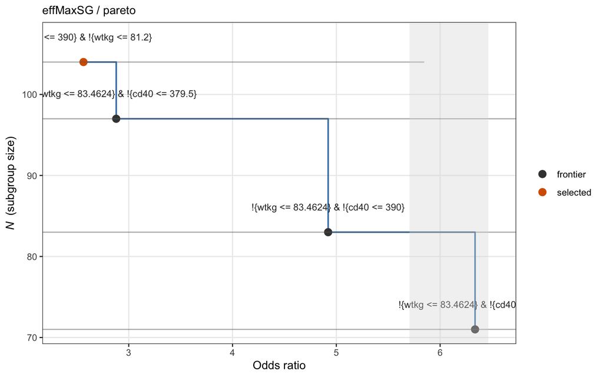

#### 5.2.1.2 effMaxSG / both

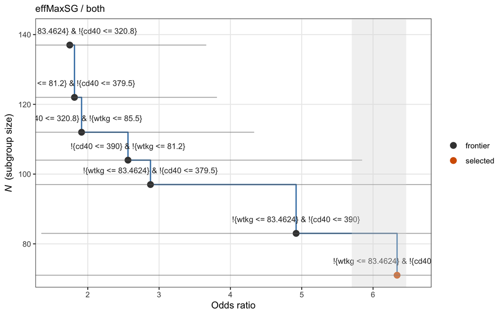

#### 5.2.1.3 effMinSG / pareto

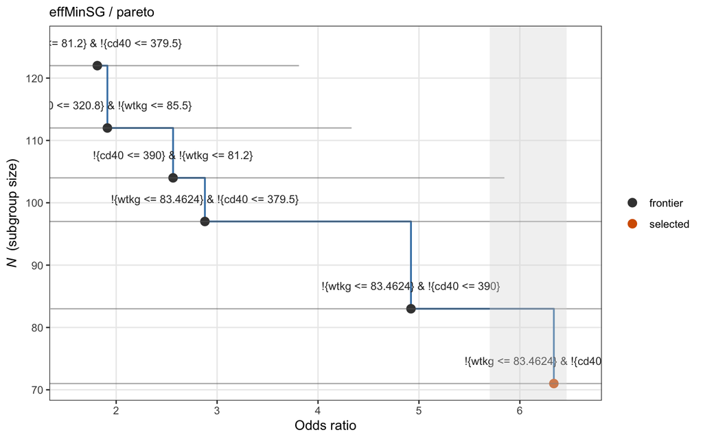

#### 5.2.1.4 effMinSG / both

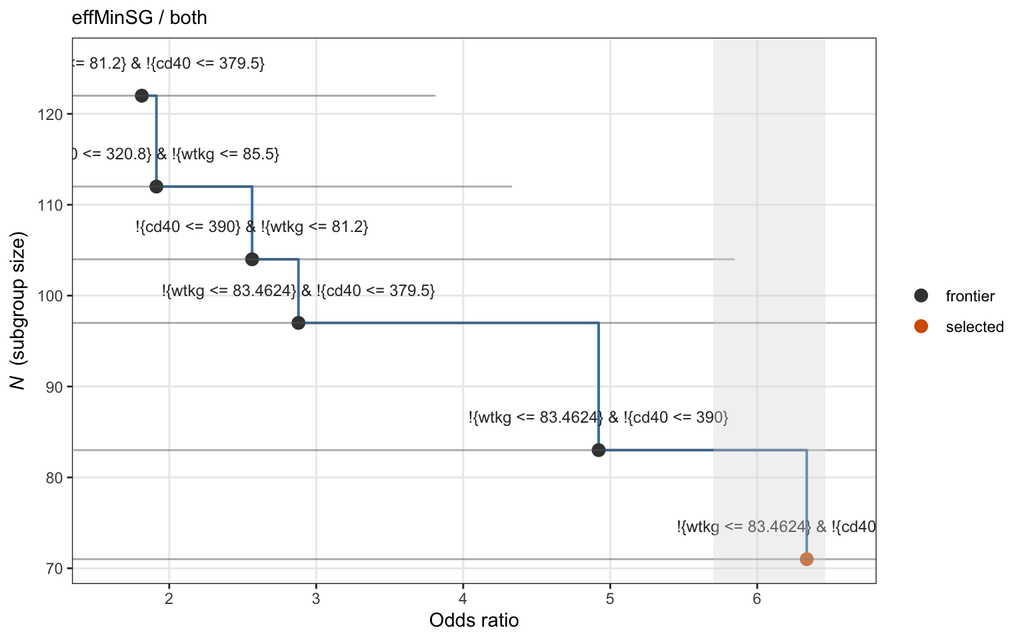

#### 5.2.1.5 eff / neighborhood

```
`geom_path()`: Each group consists of only one observation.
ℹ Do you need to adjust the group aesthetic?
```

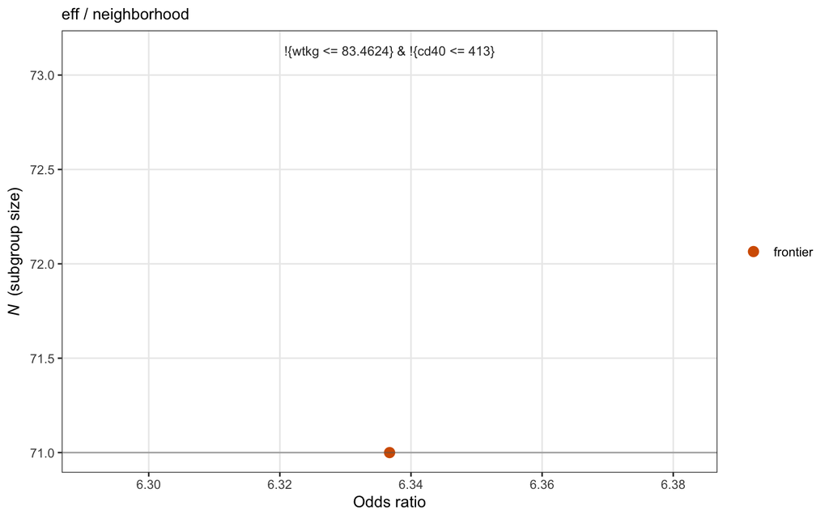

#### 5.2.1.6 maxSG / neighborhood

```
`geom_path()`: Each group consists of only one observation.
ℹ Do you need to adjust the group aesthetic?
```

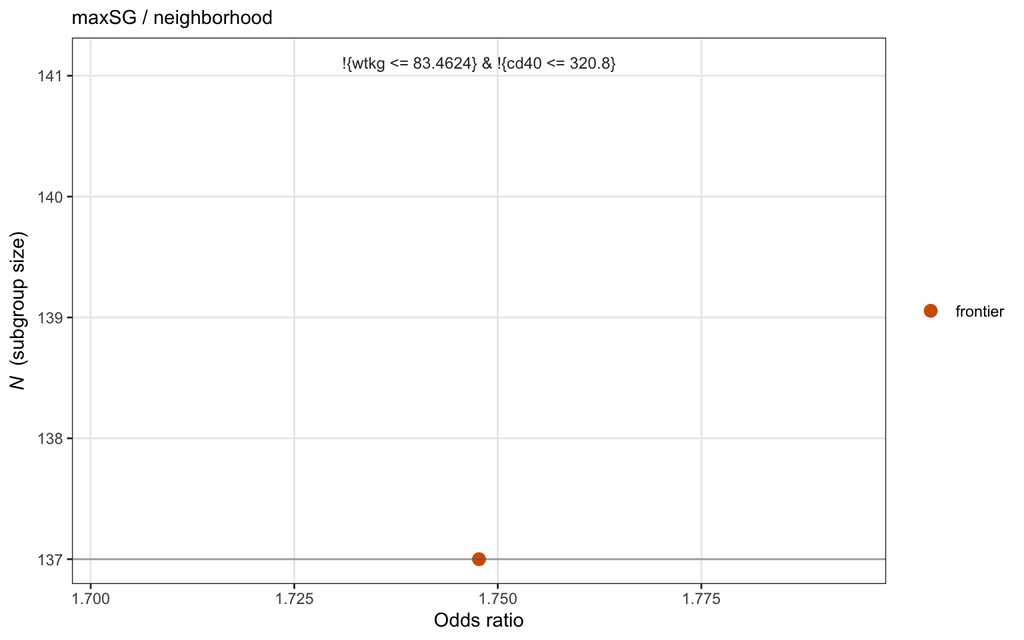

#### 5.2.1.7 minSG / neighborhood

```
`geom_path()`: Each group consists of only one observation.
ℹ Do you need to adjust the group aesthetic?
```

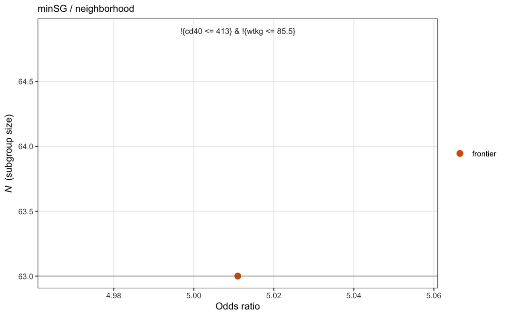

### 5.2.2 Side-by-Side Composition

```
`geom_path()`: Each group consists of only one observation.
ℹ Do you need to adjust the group aesthetic?
`geom_path()`: Each group consists of only one observation.
ℹ Do you need to adjust the group aesthetic?
`geom_path()`: Each group consists of only one observation.
ℹ Do you need to adjust the group aesthetic?
```

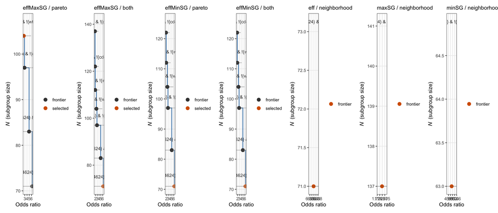

Pareto frontier across selection rules (side-by-side)

```r
print(comparison$plot_grid)
```

## 5.3 Combined Plot(s) by Matching Passing-Set Group

`compare_selection_rules()` groups configurations by their post-consistency passing set. When all configurations share one passing set, a single combined plot is built (`comparison$plot_combined`). When configurations fall into two or more matching groups – e.g. all `effMaxSG` runs agree, all `effMinSG` runs agree, but the two `sg_focus` values disagree on which candidates pass – a combined plot is built per group and stored in `comparison$plot_combined_subsets`. Each group’s plot labels its selected subgroups with `S<i>:` markers identifying the configuration(s) that picked them.

```
Passing sets fall into 1 matching group(s); one combined plot per group:

Group: effMinSG
```

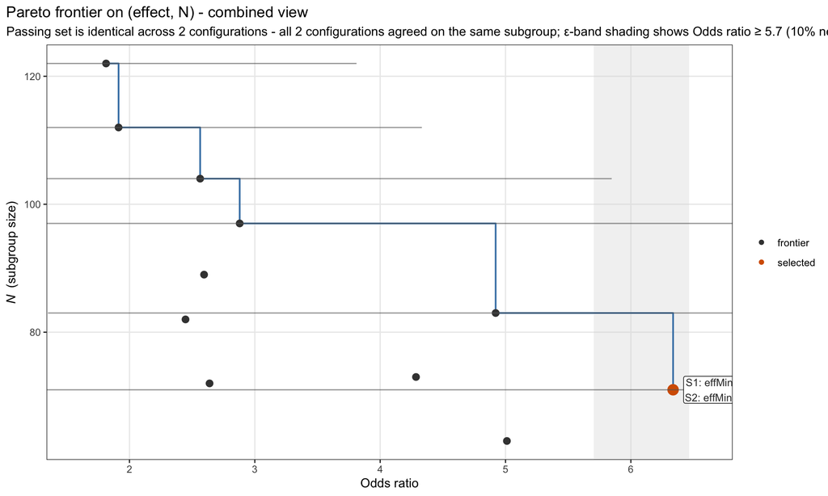

Combined Pareto frontier with S1/S2 winner annotations

```
Note: Passing sets fall into 1 matching group(s) of sizes 2; no single combined plot covers all 7 configurations.  See $plot_combined_subsets for per-group plots.
```

```r
if (!is.null(comparison$plot_combined)) {
  cat("All configurations share one passing set; single combined plot:\n\n")
  print(comparison$plot_combined)
} else if (length(comparison$plot_combined_subsets) > 0L) {
  cat(sprintf("Passing sets fall into %d matching group(s); one combined plot per group:\n\n",
              length(comparison$plot_combined_subsets)))
  for (nm in names(comparison$plot_combined_subsets)) {
    cat(sprintf("Group: %s\n", nm))
    print(comparison$plot_combined_subsets[[nm]])
  }
  if (!is.null(comparison$combined_skip_reason)) {
    cat("\nNote: ", comparison$combined_skip_reason, "\n", sep = "")
  }
} else {
  cat("**No combined plot.**\n\n")
  if (!is.null(comparison$combined_skip_reason)) {
    cat("Reason:  ", comparison$combined_skip_reason, "\n\n", sep = "")
  }
  cat("See the side-by-side composition above as the alternative view.\n")
}
```

## 5.4 Frontier Tables

Per-combination Pareto-frontier table with split-derived and FSBC CIs. Selected subgroup is highlighted with ★.

```r
for (i in seq_len(n_combos)) {
  cat(sprintf("\n### `%s`\n\n", combo_labels[i]))
  tbl <- pareto_frontier_table(
    comparison$fs[[i]],
    ci_table = comparison$ci_tab[[i]],
    digits   = frontier_params$digits
  )
  print(tbl)
  cat("\n\n")
}
```

### 5.4.1 `effMaxSG / pareto`

Pareto frontier on (OR, N)

4 non-dominated candidate(s) | sg_focus = ‘hrMaxSG’ | OR shown on natural scale (exponentiated from log-scale storage) | diagnostic only

| S<sup>1,2</sup> | M.1 | M.2 | N | E | OR | P<sup>3</sup> | K | 95% CIs Naive | 95% CIs Split ~ | 95% CIs FSBC ~ |
| --- | --- | --- | --- | --- | --- | --- | --- | --- | --- | --- |
|  | !{wtkg <= 83.4624} | !{cd40 <= 413} | 71 | 41 | 6.34 | 1.00 | 2 | (2.19, 18.37) | (0.27, 151.36) | 5.20 (0.22, 124.19) |
|  | !{wtkg <= 83.4624} | !{cd40 <= 390} | 83 | 44 | 4.92 | 1.00 | 2 | (1.93, 12.54) | (1.35, 17.96) | 4.64 (1.27, 16.94) |
|  | !{wtkg <= 83.4624} | !{cd40 <= 379.5} | 97 | 49 | 2.88 | 0.97 | 2 | (1.26, 6.57) | (1.19, 6.98) | 2.80 (1.16, 6.79) |
| ★ | !{cd40 <= 390} | !{wtkg <= 81.2} | 104 | 52 | 2.56 | 0.97 | 2 | (1.16, 5.65) | (1.12, 5.85) | 2.50 (1.10, 5.70) |

<sup>1</sup> S: selected subgroup (winner of the configured selection rule).  
<sup>2</sup> ★ marks the subgroup chosen by sg_focus = ‘hrMaxSG’.  
<sup>3</sup> P: Pcons (consistency probability).

### 5.4.2 `effMaxSG / both`

Pareto frontier on (OR, N)

7 non-dominated candidate(s) | sg_focus = ‘hrMaxSG’ | OR shown on natural scale (exponentiated from log-scale storage) | diagnostic only

| S<sup>1,2</sup> | M.1 | M.2 | N | E | OR | P<sup>3</sup> | K | 95% CIs Naive | 95% CIs Split ~ | 95% CIs FSBC ~ |
| --- | --- | --- | --- | --- | --- | --- | --- | --- | --- | --- |
| ★ | !{wtkg <= 83.4624} | !{cd40 <= 413} | 71 | 41 | 6.34 | 1.00 | 2 | (2.19, 18.37) | (0.27, 151.36) | 5.20 (0.22, 124.19) |
|  | !{wtkg <= 83.4624} | !{cd40 <= 390} | 83 | 44 | 4.92 | 1.00 | 2 | (1.93, 12.54) | (1.35, 17.96) | 4.64 (1.27, 16.94) |
|  | !{wtkg <= 83.4624} | !{cd40 <= 379.5} | 97 | 49 | 2.88 | 0.97 | 2 | (1.26, 6.57) | (1.19, 6.98) | 2.80 (1.16, 6.79) |
|  | !{cd40 <= 390} | !{wtkg <= 81.2} | 104 | 52 | 2.56 | 0.99 | 2 | (1.16, 5.65) | (1.12, 5.85) | 2.50 (1.10, 5.70) |
|  | !{cd40 <= 320.8} | !{wtkg <= 85.5} | 112 | 57 | 1.91 | 0.93 | 2 | (0.90, 4.05) | (0.84, 4.33) | 1.89 (0.83, 4.27) |
|  | !{wtkg <= 81.2} | !{cd40 <= 379.5} | 122 | 59 | 1.81 | 0.90 | 2 | (0.88, 3.72) | (0.86, 3.81) | 1.80 (0.86, 3.78) |
|  | !{wtkg <= 83.4624} | !{cd40 <= 320.8} | 137 | 65 | 1.75 | 0.95 | 2 | (0.89, 3.44) | (0.83, 3.66) | 1.73 (0.82, 3.62) |

<sup>1</sup> S: selected subgroup (winner of the configured selection rule).  
<sup>2</sup> ★ marks the subgroup chosen by sg_focus = ‘hrMaxSG’.  
<sup>3</sup> P: Pcons (consistency probability).

### 5.4.3 `effMinSG / pareto`

Pareto frontier on (OR, N)

6 non-dominated candidate(s) | sg_focus = ‘hrMinSG’ | OR shown on natural scale (exponentiated from log-scale storage) | diagnostic only

| S<sup>1,2</sup> | M.1 | M.2 | N | E | OR | P<sup>3</sup> | K | 95% CIs Naive | 95% CIs Split ~ | 95% CIs FSBC ~ |
| --- | --- | --- | --- | --- | --- | --- | --- | --- | --- | --- |
| ★ | !{wtkg <= 83.4624} | !{cd40 <= 413} | 71 | 41 | 6.34 | 1.00 | 2 | (2.19, 18.37) | (0.27, 151.36) | 5.20 (0.22, 124.19) |
|  | !{wtkg <= 83.4624} | !{cd40 <= 390} | 83 | 44 | 4.92 | 1.00 | 2 | (1.93, 12.54) | (1.35, 17.96) | 4.64 (1.27, 16.94) |
|  | !{wtkg <= 83.4624} | !{cd40 <= 379.5} | 97 | 49 | 2.88 | 1.00 | 2 | (1.26, 6.57) | (1.19, 6.98) | 2.80 (1.16, 6.79) |
|  | !{cd40 <= 390} | !{wtkg <= 81.2} | 104 | 52 | 2.56 | 0.99 | 2 | (1.16, 5.65) | (1.12, 5.85) | 2.50 (1.10, 5.70) |
|  | !{cd40 <= 320.8} | !{wtkg <= 85.5} | 112 | 57 | 1.91 | 0.95 | 2 | (0.90, 4.05) | (0.84, 4.33) | 1.89 (0.83, 4.27) |
|  | !{wtkg <= 81.2} | !{cd40 <= 379.5} | 122 | 59 | 1.81 | 0.90 | 2 | (0.88, 3.72) | (0.86, 3.81) | 1.80 (0.86, 3.78) |

<sup>1</sup> S: selected subgroup (winner of the configured selection rule).  
<sup>2</sup> ★ marks the subgroup chosen by sg_focus = ‘hrMinSG’.  
<sup>3</sup> P: Pcons (consistency probability).

### 5.4.4 `effMinSG / both`

Pareto frontier on (OR, N)

6 non-dominated candidate(s) | sg_focus = ‘hrMinSG’ | OR shown on natural scale (exponentiated from log-scale storage) | diagnostic only

| S<sup>1,2</sup> | M.1 | M.2 | N | E | OR | P<sup>3</sup> | K | 95% CIs Naive | 95% CIs Split ~ | 95% CIs FSBC ~ |
| --- | --- | --- | --- | --- | --- | --- | --- | --- | --- | --- |
| ★ | !{wtkg <= 83.4624} | !{cd40 <= 413} | 71 | 41 | 6.34 | 1.00 | 2 | (2.19, 18.37) | (0.27, 151.36) | 5.20 (0.22, 124.19) |
|  | !{wtkg <= 83.4624} | !{cd40 <= 390} | 83 | 44 | 4.92 | 1.00 | 2 | (1.93, 12.54) | (1.35, 17.96) | 4.64 (1.27, 16.94) |
|  | !{wtkg <= 83.4624} | !{cd40 <= 379.5} | 97 | 49 | 2.88 | 1.00 | 2 | (1.26, 6.57) | (1.19, 6.98) | 2.80 (1.16, 6.79) |
|  | !{cd40 <= 390} | !{wtkg <= 81.2} | 104 | 52 | 2.56 | 0.99 | 2 | (1.16, 5.65) | (1.12, 5.85) | 2.50 (1.10, 5.70) |
|  | !{cd40 <= 320.8} | !{wtkg <= 85.5} | 112 | 57 | 1.91 | 0.95 | 2 | (0.90, 4.05) | (0.84, 4.33) | 1.89 (0.83, 4.27) |
|  | !{wtkg <= 81.2} | !{cd40 <= 379.5} | 122 | 59 | 1.81 | 0.90 | 2 | (0.88, 3.72) | (0.86, 3.81) | 1.80 (0.86, 3.78) |

<sup>1</sup> S: selected subgroup (winner of the configured selection rule).  
<sup>2</sup> ★ marks the subgroup chosen by sg_focus = ‘hrMinSG’.  
<sup>3</sup> P: Pcons (consistency probability).

### 5.4.5 `eff / neighborhood`

Pareto frontier on (OR, N)

1 non-dominated candidate(s) | sg_focus = ‘hr’ | OR shown on natural scale (exponentiated from log-scale storage) | diagnostic only

| S<sup>1,2</sup> | M.1 | M.2 | N | E | OR | P<sup>3</sup> | K | 95% CIs Naive | 95% CIs Split ~ | 95% CIs FSBC ~ |
| --- | --- | --- | --- | --- | --- | --- | --- | --- | --- | --- |
| ★ | !{wtkg <= 83.4624} | !{cd40 <= 413} | 71 | 41 | 6.34 | 1.00 | 2 | (2.19, 18.37) | (0.27, 151.36) | 5.20 (0.22, 124.19) |

<sup>1</sup> S: selected subgroup (winner of the configured selection rule).  
<sup>2</sup> ★ marks the subgroup chosen by sg_focus = ‘hr’.  
<sup>3</sup> P: Pcons (consistency probability).

### 5.4.6 `maxSG / neighborhood`

Pareto frontier on (OR, N)

1 non-dominated candidate(s) | sg_focus = ‘maxSG’ | OR shown on natural scale (exponentiated from log-scale storage) | diagnostic only

| S<sup>1,2</sup> | M.1 | M.2 | N | E | OR | P<sup>3</sup> | K | 95% CIs Naive | 95% CIs Split ~ | 95% CIs FSBC ~ |
| --- | --- | --- | --- | --- | --- | --- | --- | --- | --- | --- |
| ★ | !{wtkg <= 83.4624} | !{cd40 <= 320.8} | 137 | 65 | 1.75 | 0.97 | 2 | (0.89, 3.44) | (0.86, 3.56) | 1.73 (0.85, 3.53) |

<sup>1</sup> S: selected subgroup (winner of the configured selection rule).  
<sup>2</sup> ★ marks the subgroup chosen by sg_focus = ‘maxSG’.  
<sup>3</sup> P: Pcons (consistency probability).

### 5.4.7 `minSG / neighborhood`

Pareto frontier on (OR, N)

1 non-dominated candidate(s) | sg_focus = ‘minSG’ | OR shown on natural scale (exponentiated from log-scale storage) | diagnostic only

| S<sup>1,2</sup> | M.1 | M.2 | N | E | OR | P<sup>3</sup> | K | 95% CIs Naive | 95% CIs Split ~ | 95% CIs FSBC ~ |
| --- | --- | --- | --- | --- | --- | --- | --- | --- | --- | --- |
| ★ | !{cd40 <= 413} | !{wtkg <= 85.5} | 63 | 37 | 5.01 | 1.00 | 2 | (1.67, 15.03) | (0.39, 65.18) | 4.35 (0.33, 56.56) |

<sup>1</sup> S: selected subgroup (winner of the configured selection rule).  
<sup>2</sup> ★ marks the subgroup chosen by sg_focus = ‘minSG’.  
<sup>3</sup> P: Pcons (consistency probability).

## 5.5 Selection Narratives

`explain_pareto_selection()` produces a verbal account of why the selected subgroup wins on the configured lexicographic criterion relative to the other non-dominated candidates. Reading the two narratives together highlights which axis of the lex key the two rules tie-broke on differently.

```r
for (i in seq_len(n_combos)) {
  cat(sprintf("\n### `%s`\n\n", combo_labels[i]))
  cat(explain_pareto_selection(
    comparison$fs[[i]],
    ci_table = comparison$ci_tab[[i]],
    digits   = frontier_params$digits
  ))
  cat("\n\n")
}
```

### 5.5.1 `effMaxSG / pareto`

**Selection criterion.** The configured criterion is largest-N among non-dominated candidates (sg_focus = “hrMaxSG”) under the Pareto-non-dominance rule. Within the eligible set, ties on N are broken by Pcons, then by effect strength, then by parsimony (smaller K).

**Selected subgroup.** !{cd40 <= 390} AND !{wtkg <= 81.2} (odds ratio = 2.56, N = 104, Pcons = 0.97, K = 2). This is the largest-N candidate in the eligible set among non-dominated frontier candidates. The Naive 95% CI for the odds ratio on this subgroup is (1.16, 5.65).

**Non-selected frontier candidates** (ordered by closeness to winning):

- **!{wtkg <= 83.4624} AND !{cd40 <= 379.5}** (odds ratio = 2.88, N = 97, Pcons = 0.97, K = 2). Smaller subgroup (N=97 vs N=104, 7 fewer subjects). N is the primary tiebreaker among non-dominated candidates, so this candidate’s stronger effect could not overcome the size loss.
- **!{wtkg <= 83.4624} AND !{cd40 <= 390}** (odds ratio = 4.92, N = 83, Pcons = 1.00, K = 2). Smaller subgroup (N=83 vs N=104, 21 fewer subjects). N is the primary tiebreaker among non-dominated candidates, so this candidate’s stronger effect could not overcome the size loss.
- **!{wtkg <= 83.4624} AND !{cd40 <= 413}** (odds ratio = 6.34, N = 71, Pcons = 1.00, K = 2). Smaller subgroup (N=71 vs N=104, 33 fewer subjects). N is the primary tiebreaker among non-dominated candidates, so this candidate’s stronger effect could not overcome the size loss.

### 5.5.2 `effMaxSG / both`

**Selection criterion.** The configured criterion is largest-N within the effect-size band (sg_focus = “hrMaxSG”) under the intersection of effect-band and Pareto-non-dominance rules. The effect-size band requires odds ratio within 10% of the maximum on the frontier (i.e., odds ratio >= 5.70). Within the eligible set, ties on N are broken by Pcons, then by effect strength, then by parsimony (smaller K).

**Selected subgroup.** !{wtkg <= 83.4624} AND !{cd40 <= 413} (odds ratio = 6.34, N = 71, Pcons = 1.00, K = 2). This is the largest-N candidate in the eligible set among non-dominated frontier candidates. The Naive 95% CI for the odds ratio on this subgroup is (2.19, 18.37).

**Non-selected frontier candidates** (ordered by closeness to winning):

- **!{wtkg <= 83.4624} AND !{cd40 <= 390}** (odds ratio = 4.92, N = 83, Pcons = 1.00, K = 2). fell outside the effect-size band (odds ratio = 4.92 below the floor); excluded before the N tiebreaker even applies.
- **!{wtkg <= 83.4624} AND !{cd40 <= 379.5}** (odds ratio = 2.88, N = 97, Pcons = 0.97, K = 2). fell outside the effect-size band (odds ratio = 2.88 below the floor); excluded before the N tiebreaker even applies.
- **!{cd40 <= 390} AND !{wtkg <= 81.2}** (odds ratio = 2.56, N = 104, Pcons = 0.99, K = 2). fell outside the effect-size band (odds ratio = 2.56 below the floor); excluded before the N tiebreaker even applies.
- **!{cd40 <= 320.8} AND !{wtkg <= 85.5}** (odds ratio = 1.91, N = 112, Pcons = 0.93, K = 2). fell outside the effect-size band (odds ratio = 1.91 below the floor); excluded before the N tiebreaker even applies.
- **!{wtkg <= 81.2} AND !{cd40 <= 379.5}** (odds ratio = 1.81, N = 122, Pcons = 0.90, K = 2). fell outside the effect-size band (odds ratio = 1.81 below the floor); excluded before the N tiebreaker even applies.
- **!{wtkg <= 83.4624} AND !{cd40 <= 320.8}** (odds ratio = 1.75, N = 137, Pcons = 0.95, K = 2). fell outside the effect-size band (odds ratio = 1.75 below the floor); excluded before the N tiebreaker even applies.

### 5.5.3 `effMinSG / pareto`

**Selection criterion.** The configured criterion is smallest-N among non-dominated candidates (sg_focus = “hrMinSG”) under the Pareto-non-dominance rule. Within the eligible set, ties on N are broken by Pcons, then by effect strength, then by parsimony (smaller K).

**Selected subgroup.** !{wtkg <= 83.4624} AND !{cd40 <= 413} (odds ratio = 6.34, N = 71, Pcons = 1.00, K = 2). This is the smallest-N candidate in the eligible set among non-dominated frontier candidates. The Naive 95% CI for the odds ratio on this subgroup is (2.19, 18.37).

**Non-selected frontier candidates** (ordered by closeness to winning):

- **!{wtkg <= 83.4624} AND !{cd40 <= 390}** (odds ratio = 4.92, N = 83, Pcons = 1.00, K = 2). Larger subgroup (N=83 vs N=71, 12 more subjects). N is the primary tiebreaker among non-dominated candidates, so this candidate’s comparable effect could not overcome the size loss.
- **!{wtkg <= 83.4624} AND !{cd40 <= 379.5}** (odds ratio = 2.88, N = 97, Pcons = 1.00, K = 2). Larger subgroup (N=97 vs N=71, 26 more subjects). N is the primary tiebreaker among non-dominated candidates, so this candidate’s comparable effect could not overcome the size loss.
- **!{cd40 <= 390} AND !{wtkg <= 81.2}** (odds ratio = 2.56, N = 104, Pcons = 0.99, K = 2). Larger subgroup (N=104 vs N=71, 33 more subjects). N is the primary tiebreaker among non-dominated candidates, so this candidate’s comparable effect could not overcome the size loss.
- **!{cd40 <= 320.8} AND !{wtkg <= 85.5}** (odds ratio = 1.91, N = 112, Pcons = 0.95, K = 2). Larger subgroup (N=112 vs N=71, 41 more subjects). N is the primary tiebreaker among non-dominated candidates, so this candidate’s comparable effect could not overcome the size loss.
- **!{wtkg <= 81.2} AND !{cd40 <= 379.5}** (odds ratio = 1.81, N = 122, Pcons = 0.90, K = 2). Larger subgroup (N=122 vs N=71, 51 more subjects). N is the primary tiebreaker among non-dominated candidates, so this candidate’s comparable effect could not overcome the size loss.

### 5.5.4 `effMinSG / both`

**Selection criterion.** The configured criterion is smallest-N within the effect-size band (sg_focus = “hrMinSG”) under the intersection of effect-band and Pareto-non-dominance rules. The effect-size band requires odds ratio within 10% of the maximum on the frontier (i.e., odds ratio >= 5.70). Within the eligible set, ties on N are broken by Pcons, then by effect strength, then by parsimony (smaller K).

**Selected subgroup.** !{wtkg <= 83.4624} AND !{cd40 <= 413} (odds ratio = 6.34, N = 71, Pcons = 1.00, K = 2). This is the smallest-N candidate in the eligible set among non-dominated frontier candidates. The Naive 95% CI for the odds ratio on this subgroup is (2.19, 18.37).

**Non-selected frontier candidates** (ordered by closeness to winning):

- **!{wtkg <= 83.4624} AND !{cd40 <= 390}** (odds ratio = 4.92, N = 83, Pcons = 1.00, K = 2). fell outside the effect-size band (odds ratio = 4.92 below the floor); excluded before the N tiebreaker even applies.
- **!{wtkg <= 83.4624} AND !{cd40 <= 379.5}** (odds ratio = 2.88, N = 97, Pcons = 1.00, K = 2). fell outside the effect-size band (odds ratio = 2.88 below the floor); excluded before the N tiebreaker even applies.
- **!{cd40 <= 390} AND !{wtkg <= 81.2}** (odds ratio = 2.56, N = 104, Pcons = 0.99, K = 2). fell outside the effect-size band (odds ratio = 2.56 below the floor); excluded before the N tiebreaker even applies.
- **!{cd40 <= 320.8} AND !{wtkg <= 85.5}** (odds ratio = 1.91, N = 112, Pcons = 0.95, K = 2). fell outside the effect-size band (odds ratio = 1.91 below the floor); excluded before the N tiebreaker even applies.
- **!{wtkg <= 81.2} AND !{cd40 <= 379.5}** (odds ratio = 1.81, N = 122, Pcons = 0.90, K = 2). fell outside the effect-size band (odds ratio = 1.81 below the floor); excluded before the N tiebreaker even applies.

### 5.5.5 `eff / neighborhood`

**Selection criterion.** The configured criterion is highest-consistency (sg_focus = “hr”) under the effect-size neighborhood rule.

**Selected subgroup.** !{wtkg <= 83.4624} AND !{cd40 <= 413} (odds ratio = 6.34, N = 71, Pcons = 1.00, K = 2). This is the candidate with the highest Pcons among non-dominated frontier candidates. The Naive 95% CI for the odds ratio on this subgroup is (2.19, 18.37).

**Non-selected candidates.** The frontier has a single candidate, so no comparison applies.

### 5.5.6 `maxSG / neighborhood`

**Selection criterion.** The configured criterion is largest-N (sg_focus = “maxSG”) under the effect-size neighborhood rule. Ties on N are broken by Pcons, then by parsimony (smaller K).

**Selected subgroup.** !{wtkg <= 83.4624} AND !{cd40 <= 320.8} (odds ratio = 1.75, N = 137, Pcons = 0.97, K = 2). This is the largest-N candidate among non-dominated frontier candidates. The Naive 95% CI for the odds ratio on this subgroup is (0.89, 3.44).

**Non-selected candidates.** The frontier has a single candidate, so no comparison applies.

### 5.5.7 `minSG / neighborhood`

**Selection criterion.** The configured criterion is smallest-N (sg_focus = “minSG”) under the effect-size neighborhood rule. Ties on N are broken by Pcons, then by parsimony (smaller K).

**Selected subgroup.** !{cd40 <= 413} AND !{wtkg <= 85.5} (odds ratio = 5.01, N = 63, Pcons = 1.00, K = 2). This is the smallest-N candidate among non-dominated frontier candidates. The Naive 95% CI for the odds ratio on this subgroup is (1.67, 15.03).

**Non-selected candidates.** The frontier has a single candidate, so no comparison applies.

# 6 Rich Post-Consistency View

The `include_dominated = TRUE` argument to `pareto_frontier_table()` shows **all** passing candidates (not just the frontier), with `on_frontier` and `in_band` flag columns added. This is the post-hoc analog of the `CANDIDATE EVALUATION SUMMARY` banner printed during the run.

```r
for (i in seq_len(n_combos)) {
  cat(sprintf("\n### `%s`\n\n", combo_labels[i]))
  tbl <- pareto_frontier_table(
    comparison$fs[[i]],
    ci_table          = comparison$ci_tab[[i]],
    include_dominated = TRUE,
    digits            = frontier_params$digits
  )
  print(tbl)
  cat("\n\n")
}
```

### 6.0.1 `effMaxSG / pareto`

Pareto frontier on (OR, N)

4 non-dominated candidate(s) | sg_focus = ‘hrMaxSG’ | OR shown on natural scale (exponentiated from log-scale storage) | diagnostic only

| S<sup>1,2</sup> | M.1 | M.2 | N | E | OR | P<sup>3</sup> | K | OF<sup>4</sup> | 95% CIs Naive | 95% CIs Split ~ | 95% CIs FSBC ~ |
| --- | --- | --- | --- | --- | --- | --- | --- | --- | --- | --- | --- |
| ★ | !{cd40 <= 390} | !{wtkg <= 81.2} | 104 | 52 | 2.56 | 0.97 | 2 | ★ | (1.16, 5.65) | (1.12, 5.85) | 2.50 (1.10, 5.70) |
|  | !{wtkg <= 83.4624} | !{cd40 <= 379.5} | 97 | 49 | 2.88 | 0.97 | 2 | ★ | (1.26, 6.57) | (1.19, 6.98) | 2.80 (1.16, 6.79) |
|  | !{wtkg <= 83.4624} | !{cd40 <= 390} | 83 | 44 | 4.92 | 1.00 | 2 | ★ | (1.93, 12.54) | (1.35, 17.96) | 4.64 (1.27, 16.94) |
|  | !{wtkg <= 83.4624} | !{cd40 <= 413} | 71 | 41 | 6.34 | 1.00 | 2 | ★ | (2.19, 18.37) | (0.27, 151.36) | 5.20 (0.22, 124.19) |

<sup>1</sup> S: selected subgroup (winner of the configured selection rule).  
<sup>2</sup> ★ marks the subgroup chosen by sg_focus = ‘hrMaxSG’.  
<sup>3</sup> P: Pcons (consistency probability).  
<sup>4</sup> OF: on Pareto frontier (non-dominated on (effect, N)).

### 6.0.2 `effMaxSG / both`

Pareto frontier on (OR, N)

7 non-dominated candidate(s) | sg_focus = ‘hrMaxSG’ | OR shown on natural scale (exponentiated from log-scale storage) | diagnostic only

| S<sup>1,2</sup> | M.1 | M.2 | N | E | OR | P<sup>3</sup> | K | OF<sup>4</sup> | IB<sup>5</sup> | 95% CIs Naive | 95% CIs Split ~ | 95% CIs FSBC ~ |
| --- | --- | --- | --- | --- | --- | --- | --- | --- | --- | --- | --- | --- |
| ★ | !{wtkg <= 83.4624} | !{cd40 <= 413} | 71 | 41 | 6.34 | 1.00 | 2 | ★ | ★ | (2.19, 18.37) | (0.27, 151.36) | 5.20 (0.22, 124.19) |
|  | !{wtkg <= 83.4624} | !{cd40 <= 320.8} | 137 | 65 | 1.75 | 0.95 | 2 | ★ |  | (0.89, 3.44) | (0.83, 3.66) | 1.73 (0.82, 3.62) |
|  | !{wtkg <= 81.2} | !{cd40 <= 379.5} | 122 | 59 | 1.81 | 0.90 | 2 | ★ |  | (0.88, 3.72) | (0.86, 3.81) | 1.80 (0.86, 3.78) |
|  | !{cd40 <= 320.8} | !{wtkg <= 85.5} | 112 | 57 | 1.91 | 0.93 | 2 | ★ |  | (0.90, 4.05) | (0.84, 4.33) | 1.89 (0.83, 4.27) |
|  | !{cd40 <= 390} | !{wtkg <= 81.2} | 104 | 52 | 2.56 | 0.99 | 2 | ★ |  | (1.16, 5.65) | (1.12, 5.85) | 2.50 (1.10, 5.70) |
|  | !{wtkg <= 83.4624} | !{cd40 <= 379.5} | 97 | 49 | 2.88 | 0.97 | 2 | ★ |  | (1.26, 6.57) | (1.19, 6.98) | 2.80 (1.16, 6.79) |
|  | !{wtkg <= 83.4624} | !{cd40 <= 390} | 83 | 44 | 4.92 | 1.00 | 2 | ★ |  | (1.93, 12.54) | (1.35, 17.96) | 4.64 (1.27, 16.94) |

<sup>1</sup> S: selected subgroup (winner of the configured selection rule).  
<sup>2</sup> ★ marks the subgroup chosen by sg_focus = ‘hrMaxSG’.  
<sup>3</sup> P: Pcons (consistency probability).  
<sup>4</sup> OF: on Pareto frontier (non-dominated on (effect, N)).  
<sup>5</sup> IB: in effect-size neighborhood band.

### 6.0.3 `effMinSG / pareto`

Pareto frontier on (OR, N)

11 non-dominated candidate(s) | sg_focus = ‘hrMinSG’ | OR shown on natural scale (exponentiated from log-scale storage) | diagnostic only

| S<sup>1,2</sup> | M.1 | M.2 | N | E | OR | P<sup>3</sup> | K | OF<sup>4</sup> | 95% CIs Naive | 95% CIs Split ~ | 95% CIs FSBC ~ |
| --- | --- | --- | --- | --- | --- | --- | --- | --- | --- | --- | --- |
| ★ | !{wtkg <= 83.4624} | !{cd40 <= 413} | 71 | 41 | 6.34 | 1.00 | 2 | ★ | (2.19, 18.37) | (0.27, 151.36) | 5.20 (0.22, 124.19) |
|  | !{wtkg <= 83.4624} | !{cd40 <= 390} | 83 | 44 | 4.92 | 1.00 | 2 | ★ | (1.93, 12.54) | (1.35, 17.96) | 4.64 (1.27, 16.94) |
|  | !{wtkg <= 83.4624} | !{cd40 <= 379.5} | 97 | 49 | 2.88 | 1.00 | 2 | ★ | (1.26, 6.57) | (1.19, 6.98) | 2.80 (1.16, 6.79) |
|  | !{cd40 <= 390} | !{wtkg <= 81.2} | 104 | 52 | 2.56 | 0.99 | 2 | ★ | (1.16, 5.65) | (1.12, 5.85) | 2.50 (1.10, 5.70) |
|  | !{cd40 <= 320.8} | !{wtkg <= 85.5} | 112 | 57 | 1.91 | 0.95 | 2 | ★ | (0.90, 4.05) | (0.84, 4.33) | 1.89 (0.83, 4.27) |
|  | !{wtkg <= 81.2} | !{cd40 <= 379.5} | 122 | 59 | 1.81 | 0.90 | 2 | ★ | (0.88, 3.72) | (0.86, 3.81) | 1.80 (0.86, 3.78) |
|  | !{cd40 <= 413} | !{wtkg <= 85.5} | 63 | 37 | 5.01 | 1.00 | 2 |  | NA | NA | NA |
|  | !{cd40 <= 449} | !{wtkg <= 78.1} | 72 | 43 | 2.64 | 0.99 | 2 |  | NA | NA | NA |
|  | !{cd40 <= 390} | !{wtkg <= 85.5} | 73 | 39 | 4.29 | 1.00 | 2 |  | NA | NA | NA |
|  | !{wtkg <= 85.5} | !{cd40 <= 379.5} | 82 | 43 | 2.45 | 0.95 | 2 |  | NA | NA | NA |
|  | !{cd40 <= 413} | !{wtkg <= 81.2} | 89 | 47 | 2.60 | 1.00 | 2 |  | NA | NA | NA |

<sup>1</sup> S: selected subgroup (winner of the configured selection rule).  
<sup>2</sup> ★ marks the subgroup chosen by sg_focus = ‘hrMinSG’.  
<sup>3</sup> P: Pcons (consistency probability).  
<sup>4</sup> OF: on Pareto frontier (non-dominated on (effect, N)).

### 6.0.4 `effMinSG / both`

Pareto frontier on (OR, N)

11 non-dominated candidate(s) | sg_focus = ‘hrMinSG’ | OR shown on natural scale (exponentiated from log-scale storage) | diagnostic only

| S<sup>1,2</sup> | M.1 | M.2 | N | E | OR | P<sup>3</sup> | K | OF<sup>4</sup> | IB<sup>5</sup> | 95% CIs Naive | 95% CIs Split ~ | 95% CIs FSBC ~ |
| --- | --- | --- | --- | --- | --- | --- | --- | --- | --- | --- | --- | --- |
| ★ | !{wtkg <= 83.4624} | !{cd40 <= 413} | 71 | 41 | 6.34 | 1.00 | 2 | ★ | ★ | (2.19, 18.37) | (0.27, 151.36) | 5.20 (0.22, 124.19) |
|  | !{cd40 <= 413} | !{wtkg <= 85.5} | 63 | 37 | 5.01 | 1.00 | 2 |  |  | NA | NA | NA |
|  | !{cd40 <= 449} | !{wtkg <= 78.1} | 72 | 43 | 2.64 | 0.99 | 2 |  |  | NA | NA | NA |
|  | !{cd40 <= 390} | !{wtkg <= 85.5} | 73 | 39 | 4.29 | 1.00 | 2 |  |  | NA | NA | NA |
|  | !{wtkg <= 85.5} | !{cd40 <= 379.5} | 82 | 43 | 2.45 | 0.95 | 2 |  |  | NA | NA | NA |
|  | !{wtkg <= 83.4624} | !{cd40 <= 390} | 83 | 44 | 4.92 | 1.00 | 2 | ★ |  | (1.93, 12.54) | (1.35, 17.96) | 4.64 (1.27, 16.94) |
|  | !{cd40 <= 413} | !{wtkg <= 81.2} | 89 | 47 | 2.60 | 1.00 | 2 |  |  | NA | NA | NA |
|  | !{wtkg <= 83.4624} | !{cd40 <= 379.5} | 97 | 49 | 2.88 | 1.00 | 2 | ★ |  | (1.26, 6.57) | (1.19, 6.98) | 2.80 (1.16, 6.79) |
|  | !{cd40 <= 390} | !{wtkg <= 81.2} | 104 | 52 | 2.56 | 0.99 | 2 | ★ |  | (1.16, 5.65) | (1.12, 5.85) | 2.50 (1.10, 5.70) |
|  | !{cd40 <= 320.8} | !{wtkg <= 85.5} | 112 | 57 | 1.91 | 0.95 | 2 | ★ |  | (0.90, 4.05) | (0.84, 4.33) | 1.89 (0.83, 4.27) |
|  | !{wtkg <= 81.2} | !{cd40 <= 379.5} | 122 | 59 | 1.81 | 0.90 | 2 | ★ |  | (0.88, 3.72) | (0.86, 3.81) | 1.80 (0.86, 3.78) |

<sup>1</sup> S: selected subgroup (winner of the configured selection rule).  
<sup>2</sup> ★ marks the subgroup chosen by sg_focus = ‘hrMinSG’.  
<sup>3</sup> P: Pcons (consistency probability).  
<sup>4</sup> OF: on Pareto frontier (non-dominated on (effect, N)).  
<sup>5</sup> IB: in effect-size neighborhood band.

### 6.0.5 `eff / neighborhood`

Pareto frontier on (OR, N)

1 non-dominated candidate(s) | sg_focus = ‘hr’ | OR shown on natural scale (exponentiated from log-scale storage) | diagnostic only

| S<sup>1,2</sup> | M.1 | M.2 | N | E | OR | P<sup>3</sup> | K | OF<sup>4</sup> | 95% CIs Naive | 95% CIs Split ~ | 95% CIs FSBC ~ |
| --- | --- | --- | --- | --- | --- | --- | --- | --- | --- | --- | --- |
| ★ | !{wtkg <= 83.4624} | !{cd40 <= 413} | 71 | 41 | 6.34 | 1.00 | 2 | ★ | (2.19, 18.37) | (0.27, 151.36) | 5.20 (0.22, 124.19) |

<sup>1</sup> S: selected subgroup (winner of the configured selection rule).  
<sup>2</sup> ★ marks the subgroup chosen by sg_focus = ‘hr’.  
<sup>3</sup> P: Pcons (consistency probability).  
<sup>4</sup> OF: on Pareto frontier (non-dominated on (effect, N)).

### 6.0.6 `maxSG / neighborhood`

Pareto frontier on (OR, N)

1 non-dominated candidate(s) | sg_focus = ‘maxSG’ | OR shown on natural scale (exponentiated from log-scale storage) | diagnostic only

| S<sup>1,2</sup> | M.1 | M.2 | N | E | OR | P<sup>3</sup> | K | OF<sup>4</sup> | 95% CIs Naive | 95% CIs Split ~ | 95% CIs FSBC ~ |
| --- | --- | --- | --- | --- | --- | --- | --- | --- | --- | --- | --- |
| ★ | !{wtkg <= 83.4624} | !{cd40 <= 320.8} | 137 | 65 | 1.75 | 0.97 | 2 | ★ | (0.89, 3.44) | (0.86, 3.56) | 1.73 (0.85, 3.53) |

<sup>1</sup> S: selected subgroup (winner of the configured selection rule).  
<sup>2</sup> ★ marks the subgroup chosen by sg_focus = ‘maxSG’.  
<sup>3</sup> P: Pcons (consistency probability).  
<sup>4</sup> OF: on Pareto frontier (non-dominated on (effect, N)).

### 6.0.7 `minSG / neighborhood`

Pareto frontier on (OR, N)

1 non-dominated candidate(s) | sg_focus = ‘minSG’ | OR shown on natural scale (exponentiated from log-scale storage) | diagnostic only

| S<sup>1,2</sup> | M.1 | M.2 | N | E | OR | P<sup>3</sup> | K | OF<sup>4</sup> | 95% CIs Naive | 95% CIs Split ~ | 95% CIs FSBC ~ |
| --- | --- | --- | --- | --- | --- | --- | --- | --- | --- | --- | --- |
| ★ | !{cd40 <= 413} | !{wtkg <= 85.5} | 63 | 37 | 5.01 | 1.00 | 2 | ★ | (1.67, 15.03) | (0.39, 65.18) | 4.35 (0.33, 56.56) |

<sup>1</sup> S: selected subgroup (winner of the configured selection rule).  
<sup>2</sup> ★ marks the subgroup chosen by sg_focus = ‘minSG’.  
<sup>3</sup> P: Pcons (consistency probability).  
<sup>4</sup> OF: on Pareto frontier (non-dominated on (effect, N)).

# 7 Programmatic Access (Reference)

```r
# Each combination's full fs object is available for downstream use.
# Index with [[i]] where i runs from 1 to n_combos; see comparison$combos
# for the (sg_focus, selection_rule, label) tuple at each index.
comparison$combos                    # data.frame: per-combo configuration
comparison$fs[[1]]                   # fs object for combo 1

# CI tables (data.tables, one per combo):
comparison$ci_tab[[1]]

# Plot objects (ggplot, one per combo):
comparison$plots[[1]]

# Side-by-side panel (single patchwork object):
comparison$plot_grid

# Combined plot (when passing sets match), and the reason if skipped:
comparison$plot_combined             # ggplot or NULL (all combos match)
comparison$plot_combined_subsets     # named list of ggplots, one per
                                     # matching subset of size >= 2
comparison$combined_skip_reason      # character or NULL

# Console output (full captured stdout, one character per line):
comparison$console[[1]]

# Diagnostics (filtered slices: preview, summary, full):
comparison$diagnostics[[1]]$preview  # PREVIEW block as single string
comparison$diagnostics[[1]]$summary  # SUMMARY block as single string
comparison$diagnostics[[1]]$full     # entire captured stdout (single string)

# Errors (NULL if combo succeeded):
comparison$errors[[1]]
```

# 8 Selected Subgroups (Tidy Summary)

`extract_selected_subgroups()` reduces the per-combo results to a tidy one-row-per-configuration data.frame. Saved to disk below so a separate post-hoc document can `rbind()` this analysis’s summary with a continuous or count analysis’s summary into a single side-by-side table.

```r
selected_tidy <- extract_selected_subgroups(comparison,
                                            analysis_label = "binary")
selected_tidy
```

```
  analysis combo          combo_label sg_focus selection_rule outcome_type
1   binary     1    effMaxSG / pareto effMaxSG         pareto       binary
2   binary     2      effMaxSG / both effMaxSG           both       binary
3   binary     3    effMinSG / pareto effMinSG         pareto       binary
4   binary     4      effMinSG / both effMinSG           both       binary
5   binary     5   eff / neighborhood      eff   neighborhood       binary
6   binary     6 maxSG / neighborhood    maxSG   neighborhood       binary
7   binary     7 minSG / neighborhood    minSG   neighborhood       binary
  effect_measure                              subgroup N_H N_Hc   effect Pcons
1             OR      !{cd40 <= 390} & !{wtkg <= 81.2} 104  979 2.563910  0.97
2             OR   !{wtkg <= 83.4624} & !{cd40 <= 413}  71 1012 6.336735  1.00
3             OR   !{wtkg <= 83.4624} & !{cd40 <= 413}  71 1012 6.336735  1.00
4             OR   !{wtkg <= 83.4624} & !{cd40 <= 413}  71 1012 6.336735  1.00
5             OR   !{wtkg <= 83.4624} & !{cd40 <= 413}  71 1012 6.336735  1.00
6             OR !{wtkg <= 83.4624} & !{cd40 <= 320.8} 137  946 1.747696  0.97
7             OR      !{cd40 <= 413} & !{wtkg <= 85.5}  63 1020 5.010989  1.00
  K n_passed on_frontier error
1 2        4        TRUE  <NA>
2 2        7        TRUE  <NA>
3 2       11        TRUE  <NA>
4 2       11        TRUE  <NA>
5 2        1        TRUE  <NA>
6 2        1        TRUE  <NA>
7 2        1        TRUE  <NA>
```

```r
# Compact gt rendering: drop columns that are uniform within an analysis
# (outcome_type, effect_measure) and the error column (NA on success).
disp_cols <- setdiff(
  names(selected_tidy),
  c("outcome_type", "effect_measure", "error", "analysis")
)
gt::gt(selected_tidy[, disp_cols, drop = FALSE]) |>
  gt::tab_header(
    title    = "Selected Subgroups Across Configurations",
    subtitle = sprintf("Binary outcome (effect = %s)",
                       unique(stats::na.omit(selected_tidy$effect_measure)))
  ) |>
  gt::fmt_number(columns = c("effect", "Pcons"), decimals = 3) |>
  gt::sub_missing(missing_text = "—")
```

Selected Subgroups Across Configurations

Binary outcome (effect = OR)

| combo | combo_label | sg_focus | selection_rule | subgroup | N_H | N_Hc | effect | Pcons | K | n_passed | on_frontier |
| --- | --- | --- | --- | --- | --- | --- | --- | --- | --- | --- | --- |
| 1 | effMaxSG / pareto | effMaxSG | pareto | !{cd40 <= 390} & !{wtkg <= 81.2} | 104 | 979 | 2.564 | 0.970 | 2 | 4 | TRUE |
| 2 | effMaxSG / both | effMaxSG | both | !{wtkg <= 83.4624} & !{cd40 <= 413} | 71 | 1012 | 6.337 | 1.000 | 2 | 7 | TRUE |
| 3 | effMinSG / pareto | effMinSG | pareto | !{wtkg <= 83.4624} & !{cd40 <= 413} | 71 | 1012 | 6.337 | 1.000 | 2 | 11 | TRUE |
| 4 | effMinSG / both | effMinSG | both | !{wtkg <= 83.4624} & !{cd40 <= 413} | 71 | 1012 | 6.337 | 1.000 | 2 | 11 | TRUE |
| 5 | eff / neighborhood | eff | neighborhood | !{wtkg <= 83.4624} & !{cd40 <= 413} | 71 | 1012 | 6.337 | 1.000 | 2 | 1 | TRUE |
| 6 | maxSG / neighborhood | maxSG | neighborhood | !{wtkg <= 83.4624} & !{cd40 <= 320.8} | 137 | 946 | 1.748 | 0.970 | 2 | 1 | TRUE |
| 7 | minSG / neighborhood | minSG | neighborhood | !{cd40 <= 413} & !{wtkg <= 85.5} | 63 | 1020 | 5.011 | 1.000 | 2 | 1 | TRUE |

```r
# Persist both (a) the tidy selected-subgroups summary -- compact, easy
# to read across documents -- and (b) the full comparison object for
# anyone who needs to drill into per-combo plots, CIs, or captured
# diagnostics in the post-hoc document.
# Destination is `output_dir` (defined in the analysis-params chunk at
# the top of this document).
saveRDS(selected_tidy,
        file = file.path(output_dir, "selected_subgroups_binary.rds"))
saveRDS(comparison,
        file = file.path(output_dir, "comparison_binary.rds"))

cat("Output directory: ", normalizePath(output_dir), "\n", sep = "")
```

```
Output directory: /Users/larryleon/Documents/GitHub/forestsearch/quarto/applications/_data
```

```r
cat("Saved tidy summary:        selected_subgroups_binary.rds\n")
```

```
Saved tidy summary:        selected_subgroups_binary.rds
```

```r
cat("Saved full comparison:     comparison_binary.rds\n")
```

```
Saved full comparison:     comparison_binary.rds
```

```r
cat(sprintf("(tidy rows: %d; comparison combos: %d)\n",
            nrow(selected_tidy), nrow(comparison$combos)))
```

```
(tidy rows: 7; comparison combos: 7)
```

# 9 Computational Timing

```r
timings$total <- (proc.time() - t_doc_start)["elapsed"]

timing_df <- data.frame(
  Component = c(sprintf("Comparison run (%d combos)", n_combos),
                "Total document"),
  Seconds   = c(timings$compare, timings$total)
)
timing_df$Minutes <- timing_df$Seconds / 60

gt(timing_df) |>
  tab_header(title = "Computational Timing") |>
  fmt_number(columns = c(Seconds, Minutes), decimals = 1) |>
  cols_label(
    Component = "Component",
    Seconds   = "Time (sec)",
    Minutes   = "Time (min)"
  )
```

Computational Timing

| Component | Time (sec) | Time (min) |
| --- | --- | --- |
| Comparison run (7 combos) | 106.0 | 1.8 |
| Total document | 116.9 | 1.9 |

# 10 References

León LA, Ye J, Zhao H. *A Bootstrap Framework for Subgroup Identification in Randomized Clinical Trials with Bias Correction.* Statistics in Medicine. 2024. [doi:10.1002/sim.10163](https://doi.org/10.1002/sim.10163)